# Sparkify Project Workspace

This workspace contains a **tiny subset (128MB)** of the full dataset available (12GB). Feel free to use this workspace to build your project, or to explore a smaller subset with Spark before deploying your cluster on the cloud. Instructions for setting up your Spark cluster is included in the last lesson of the Extracurricular Spark Course content.

You can follow the steps below to guide your data analysis and model building portion of this project.

```python
# import libraries
from pyspark import SparkConf
from pyspark.sql import SparkSession
from pyspark.sql import Window

from pyspark.sql.functions import *
from pyspark.sql.types import *

import numpy as np
import pandas as pd
import datetime
from time import time
import matplotlib.pyplot as plt
import matplotlib.colors as mcolors
import seaborn as sns

from pyspark.ml import Pipeline
from pyspark.ml.feature import StringIndexer, OneHotEncoderEstimator, VectorAssembler, MinMaxScaler
from pyspark.ml.classification import (NaiveBayes, LogisticRegression, DecisionTreeClassifier,
                                       RandomForestClassifier, LinearSVC)
from pyspark.ml.evaluation import MulticlassClassificationEvaluator, BinaryClassificationEvaluator
from pyspark.ml.tuning import CrossValidator, ParamGridBuilder

%matplotlib inline
```

```python
# Set color palette for graphs
sns.set_palette('pastel')
```

```python
# show all columns of pandas dataframes, adjust column and display width automatically in notebook
# source: https://stackoverflow.com/questions/11707586/how-do-i-expand-the-output-display-to-see-more-
# columns-of-a-pandas-dataframe
pd.set_option('display.max_columns', None)
pd.set_option('display.expand_frame_repr', False)
pd.set_option('max_colwidth', -1)
```

```python
# create a Spark session
spark = SparkSession \
    .builder \
    .appName("Sparkify") \
    .getOrCreate()
```

```python
# check that our Spark session has been created
spark.sparkContext.getConf().getAll()
spark
```

**SparkSession - in-memory**

**SparkContext**

[Spark UI](http://8b7ab2b57a04:4040)

**Version**

`v2.4.3`

**Master**

`local[*]`

**AppName**

`Sparkify`

# Load and Clean Dataset

In this workspace, the mini-dataset file is `mini_sparkify_event_data.json`. Load and clean the dataset, checking for invalid or missing data - for example, records without userids or sessionids.

```python
# define path to and load json file as dataframe
path = "mini_sparkify_event_data.json"
df = spark.read.json(path)
```

```python
# print schema to check dataframe structure
df.printSchema()
```

```
root
 |-- artist: string (nullable = true)
 |-- auth: string (nullable = true)
 |-- firstName: string (nullable = true)
 |-- gender: string (nullable = true)
 |-- itemInSession: long (nullable = true)
 |-- lastName: string (nullable = true)
 |-- length: double (nullable = true)
 |-- level: string (nullable = true)
 |-- location: string (nullable = true)
 |-- method: string (nullable = true)
 |-- page: string (nullable = true)
 |-- registration: long (nullable = true)
 |-- sessionId: long (nullable = true)
 |-- song: string (nullable = true)
 |-- status: long (nullable = true)
 |-- ts: long (nullable = true)
 |-- userAgent: string (nullable = true)
 |-- userId: string (nullable = true)
```

```python
# number of columns in dataframe
len(df.columns)
```

```
18
```

**There are 18 columns in the dataframe, of which 12 are strings and 6 are numerical.**

```python
# number of samples in dataframe
df.count()
```

```
286500
```

```python
# print first 5 rows as pandas dataframe
df.toPandas().head(5)
```

|  | artist | auth | firstName | gender | itemInSession | lastName | length | level | location | method | page | registration | sessionId | song | status | ts | userAgent | userId |
| --- | --- | --- | --- | --- | --- | --- | --- | --- | --- | --- | --- | --- | --- | --- | --- | --- | --- | --- |
| 0 | Martha Tilston | Logged In | Colin | M | 50 | Freeman | 277.89016 | paid | Bakersfield, CA | PUT | NextSong | 1.538173e+12 | 29 | Rockpools | 200 | 1538352117000 | Mozilla/5.0 (Windows NT 6.1; WOW64; rv:31.0) Gecko/20100101 Firefox/31.0 | 30 |
| 1 | Five Iron Frenzy | Logged In | Micah | M | 79 | Long | 236.09424 | free | Boston-Cambridge-Newton, MA-NH | PUT | NextSong | 1.538332e+12 | 8 | Canada | 200 | 1538352180000 | "Mozilla/5.0 (Windows NT 6.1; WOW64) AppleWebKit/537.36 (KHTML, like Gecko) Chrome/37.0.2062.103 Safari/537.36" | 9 |
| 2 | Adam Lambert | Logged In | Colin | M | 51 | Freeman | 282.82730 | paid | Bakersfield, CA | PUT | NextSong | 1.538173e+12 | 29 | Time For Miracles | 200 | 1538352394000 | Mozilla/5.0 (Windows NT 6.1; WOW64; rv:31.0) Gecko/20100101 Firefox/31.0 | 30 |
| 3 | Enigma | Logged In | Micah | M | 80 | Long | 262.71302 | free | Boston-Cambridge-Newton, MA-NH | PUT | NextSong | 1.538332e+12 | 8 | Knocking On Forbidden Doors | 200 | 1538352416000 | "Mozilla/5.0 (Windows NT 6.1; WOW64) AppleWebKit/537.36 (KHTML, like Gecko) Chrome/37.0.2062.103 Safari/537.36" | 9 |
| 4 | Daft Punk | Logged In | Colin | M | 52 | Freeman | 223.60771 | paid | Bakersfield, CA | PUT | NextSong | 1.538173e+12 | 29 | Harder Better Faster Stronger | 200 | 1538352676000 | Mozilla/5.0 (Windows NT 6.1; WOW64; rv:31.0) Gecko/20100101 Firefox/31.0 | 30 |

**There appears to be 'None' and 'NaN' values in some columns and multiple rows/events for the same 'userId'. 'registration' and 'ts' seem to be timestamps, which should be transformed into more useful formats, such as time/day/month/year or similar. The 'location' column could be split into two separate columns with location name and postal abbreviation.**

```python
df.describe(['artist']).show()
```

```
+-------+------------------+
|summary|            artist|
+-------+------------------+
|  count|            228108|
|   mean| 551.0852017937219|
| stddev|1217.7693079161374|
|    min|               !!!|
|    max| ÃÂlafur Arnalds|
+-------+------------------+
```

**There seems to be some weird formatting in the column with artist names, 'Ãlafur Arnalds' doesn't seem correct and I'm not sure '!!!' is an artist or band. It might be best to reformat this column later on.**

```python
df.describe(['auth', 'firstName', 'gender', 'itemInSession', 'lastName', 'length', 'level', 'location']).show()
```

```
+-------+----------+---------+------+------------------+--------+-----------------+------+-----------------+
|summary|      auth|firstName|gender|     itemInSession|lastName|           length| level|         location|
+-------+----------+---------+------+------------------+--------+-----------------+------+-----------------+
|  count|    286500|   278154|278154|            286500|  278154|           228108|286500|           278154|
|   mean|      null|     null|  null|114.41421291448516|    null|249.1171819778458|  null|             null|
| stddev|      null|     null|  null|129.76726201140994|    null|99.23517921058361|  null|             null|
|    min| Cancelled| Adelaida|     F|                 0|   Adams|          0.78322|  free|       Albany, OR|
|    max|Logged Out|   Zyonna|     M|              1321|  Wright|       3024.66567|  paid|Winston-Salem, NC|
+-------+----------+---------+------+------------------+--------+-----------------+------+-----------------+
```

```python
df.groupBy('auth').count().sort(desc('count')).show()
```

```
+----------+------+
|      auth| count|
+----------+------+
| Logged In|278102|
|Logged Out|  8249|
|     Guest|    97|
| Cancelled|    52|
+----------+------+
```

```python
df.groupBy('gender').count().sort(desc('count')).show()
```

```
+------+------+
|gender| count|
+------+------+
|     F|154578|
|     M|123576|
|  null|  8346|
+------+------+
```

**the 'gender' column appears to have some null values.**

```python
df.groupBy('level').count().sort(desc('count')).show()
```

```
+-----+------+
|level| count|
+-----+------+
| paid|228162|
| free| 58338|
+-----+------+
```

```python
df.describe(['method', 'page', 'registration', 'sessionId']).show()
```

```
+-------+------+-------+--------------------+-----------------+
|summary|method|   page|        registration|        sessionId|
+-------+------+-------+--------------------+-----------------+
|  count|286500| 286500|              278154|           286500|
|   mean|  null|   null|1.535358834084427...|1041.526554973822|
| stddev|  null|   null| 3.291321616327586E9|726.7762634630741|
|    min|   GET|  About|       1521380675000|                1|
|    max|   PUT|Upgrade|       1543247354000|             2474|
+-------+------+-------+--------------------+-----------------+
```

```python
df.groupBy('method').count().sort(desc('count')).show()
```

```
+------+------+
|method| count|
+------+------+
|   PUT|261064|
|   GET| 25436|
+------+------+
```

```python
df.groupBy('page').count().sort(desc('count')).show(30, truncate=False)
```

```
+-------------------------+------+
|page                     |count |
+-------------------------+------+
|NextSong                 |228108|
|Home                     |14457 |
|Thumbs Up                |12551 |
|Add to Playlist          |6526  |
|Add Friend               |4277  |
|Roll Advert              |3933  |
|Login                    |3241  |
|Logout                   |3226  |
|Thumbs Down              |2546  |
|Downgrade                |2055  |
|Help                     |1726  |
|Settings                 |1514  |
|About                    |924   |
|Upgrade                  |499   |
|Save Settings            |310   |
|Error                    |258   |
|Submit Upgrade           |159   |
|Submit Downgrade         |63    |
|Cancel                   |52    |
|Cancellation Confirmation|52    |
|Register                 |18    |
|Submit Registration      |5     |
+-------------------------+------+
```

```python
df.describe(['song']).show()
```

```
+-------+--------------------+
|summary|                song|
+-------+--------------------+
|  count|              228108|
|   mean|            Infinity|
| stddev|                 NaN|
|    min|ÃÂg ÃÂtti Gr...|
|    max|ÃÂau hafa slopp...|
+-------+--------------------+
```

**Some weird formatting is present in the 'song' column as well.**

```python
df.describe(['status', 'ts', 'userAgent', 'userId']).show()
```

```
+-------+------------------+--------------------+--------------------+-----------------+
|summary|            status|                  ts|           userAgent|           userId|
+-------+------------------+--------------------+--------------------+-----------------+
|  count|            286500|              286500|              278154|           286500|
|   mean|210.05459685863875|1.540956889810483...|                null|59682.02278593872|
| stddev| 31.50507848842214|1.5075439608226302E9|                null|109091.9499991047|
|    min|               200|       1538352117000|"Mozilla/5.0 (Mac...|                 |
|    max|               404|       1543799476000|Mozilla/5.0 (comp...|               99|
+-------+------------------+--------------------+--------------------+-----------------+
```

**There appears to be empty strings in the 'userId' column.**

```python
df.groupBy('status').count().show()
```

```
+------+------+
|status| count|
+------+------+
|   307| 26430|
|   404|   258|
|   200|259812|
+------+------+
```

```python
# find NaNs and Nulls in dataframe
# source: https://stackoverflow.com/questions/44627386/how-to-find-count-of-null-and-nan-values-for-each-column-in-a-pyspark-dataframe
df.select([count(when(isnan(c) | col(c).isNull(), c)).alias(c) for c in df.columns]).show()
```

```
+------+----+---------+------+-------------+--------+------+-----+--------+------+----+------------+---------+-----+------+---+---------+------+
|artist|auth|firstName|gender|itemInSession|lastName|length|level|location|method|page|registration|sessionId| song|status| ts|userAgent|userId|
+------+----+---------+------+-------------+--------+------+-----+--------+------+----+------------+---------+-----+------+---+---------+------+
| 58392|   0|     8346|  8346|            0|    8346| 58392|    0|    8346|     0|   0|        8346|        0|58392|     0|  0|     8346|     0|
+------+----+---------+------+-------------+--------+------+-----+--------+------+----+------------+---------+-----+------+---+---------+------+
```

**'firstName', 'gender', 'lastName', 'location', 'registration' and 'userAgent' seem to be columns with user related information. All of these have the same number of missing values, 8346, which probably means there is no user information for these rows (events). This could be because no user was logged in for this event.**

**'artist', 'length' and 'song' seem to be related to the song played per event. These columns have the same number of missing values, 58392, which probably means there is no song/artist information recorded for this event. This might be because the event was some other than a song being played.**

```python
# find empty strings in dataframe
df.select([count(when(col(c) == '', c)).alias(c) for c in df.columns]).show()
```

```
+------+----+---------+------+-------------+--------+------+-----+--------+------+----+------------+---------+----+------+---+---------+------+
|artist|auth|firstName|gender|itemInSession|lastName|length|level|location|method|page|registration|sessionId|song|status| ts|userAgent|userId|
+------+----+---------+------+-------------+--------+------+-----+--------+------+----+------------+---------+----+------+---+---------+------+
|     0|   0|        0|     0|            0|       0|     0|    0|       0|     0|   0|           0|        0|   0|     0|  0|        0|  8346|
+------+----+---------+------+-------------+--------+------+-----+--------+------+----+------------+---------+----+------+---+---------+------+
```

**Only the 'userId' column seems to contain empty strings, which is the same number of missing values as for the other user related columns above.**

```python
# show first 20 rows with empty 'userId' as pandas dataframe
df.where(col('userId') == '').toPandas().head(20)
```

|  | artist | auth | firstName | gender | itemInSession | lastName | length | level | location | method | page | registration | sessionId | song | status | ts | userAgent | userId |
| --- | --- | --- | --- | --- | --- | --- | --- | --- | --- | --- | --- | --- | --- | --- | --- | --- | --- | --- |
| 0 | None | Logged Out | None | None | 100 | None | None | free | None | GET | Home | None | 8 | None | 200 | 1538355745000 | None |  |
| 1 | None | Logged Out | None | None | 101 | None | None | free | None | GET | Help | None | 8 | None | 200 | 1538355807000 | None |  |
| 2 | None | Logged Out | None | None | 102 | None | None | free | None | GET | Home | None | 8 | None | 200 | 1538355841000 | None |  |
| 3 | None | Logged Out | None | None | 103 | None | None | free | None | PUT | Login | None | 8 | None | 307 | 1538355842000 | None |  |
| 4 | None | Logged Out | None | None | 2 | None | None | free | None | GET | Home | None | 240 | None | 200 | 1538356678000 | None |  |
| 5 | None | Logged Out | None | None | 3 | None | None | free | None | PUT | Login | None | 240 | None | 307 | 1538356679000 | None |  |
| 6 | None | Logged Out | None | None | 0 | None | None | free | None | PUT | Login | None | 100 | None | 307 | 1538358102000 | None |  |
| 7 | None | Logged Out | None | None | 0 | None | None | free | None | PUT | Login | None | 241 | None | 307 | 1538360117000 | None |  |
| 8 | None | Logged Out | None | None | 14 | None | None | free | None | GET | Home | None | 187 | None | 200 | 1538361527000 | None |  |
| 9 | None | Logged Out | None | None | 15 | None | None | free | None | PUT | Login | None | 187 | None | 307 | 1538361528000 | None |  |
| 10 | None | Logged Out | None | None | 21 | None | None | free | None | GET | Home | None | 187 | None | 200 | 1538362007000 | None |  |
| 11 | None | Logged Out | None | None | 22 | None | None | free | None | GET | Home | None | 187 | None | 200 | 1538362095000 | None |  |
| 12 | None | Logged Out | None | None | 23 | None | None | free | None | PUT | Login | None | 187 | None | 307 | 1538362096000 | None |  |
| 13 | None | Logged Out | None | None | 0 | None | None | free | None | GET | Home | None | 27 | None | 200 | 1538363488000 | None |  |
| 14 | None | Logged Out | None | None | 1 | None | None | free | None | GET | About | None | 27 | None | 200 | 1538363494000 | None |  |
| 15 | None | Logged Out | None | None | 2 | None | None | free | None | GET | Home | None | 27 | None | 200 | 1538363503000 | None |  |
| 16 | None | Logged Out | None | None | 38 | None | None | free | None | GET | Home | None | 187 | None | 200 | 1538364254000 | None |  |
| 17 | None | Logged Out | None | None | 39 | None | None | free | None | PUT | Login | None | 187 | None | 307 | 1538364255000 | None |  |
| 18 | None | Logged Out | None | None | 0 | None | None | free | None | GET | Home | None | 257 | None | 200 | 1538364750000 | None |  |
| 19 | None | Logged Out | None | None | 47 | None | None | free | None | GET | Home | None | 100 | None | 200 | 1538370681000 | None |  |

**It seems like most rows with empty 'userId' has value 'Logged Out' in column 'auth'.**

```python
# print distinct values for column 'auth' where 'userId' is empty
df.select('auth').where(col('userId') == '').distinct().show()
```

```
+----------+
|      auth|
+----------+
|Logged Out|
|     Guest|
+----------+
```

**Above, we can see that all rows with empty 'userId' has value 'Logged Out' or 'Guest' in column 'auth'. This explains why there is no user data available for these rows. Since we're interested in looking at user behavior, these rows can't help us much since we don't know to which user these events belong to and it seems like the best option is to not include these rows in our analysis.**

```python
# show first 20 rows with missing values in 'artist' as pandas dataframe
df.where(isnan(df['artist']) | df['artist'].isNull()).toPandas().head(20)
```

|  | artist | auth | firstName | gender | itemInSession | lastName | length | level | location | method | page | registration | sessionId | song | status | ts | userAgent | userId |
| --- | --- | --- | --- | --- | --- | --- | --- | --- | --- | --- | --- | --- | --- | --- | --- | --- | --- | --- |
| 0 | None | Logged In | Colin | M | 54 | Freeman | None | paid | Bakersfield, CA | PUT | Add to Playlist | 1.538173e+12 | 29 | None | 200 | 1538352905000 | Mozilla/5.0 (Windows NT 6.1; WOW64; rv:31.0) Gecko/20100101 Firefox/31.0 | 30 |
| 1 | None | Logged In | Micah | M | 84 | Long | None | free | Boston-Cambridge-Newton, MA-NH | GET | Roll Advert | 1.538332e+12 | 8 | None | 200 | 1538353150000 | "Mozilla/5.0 (Windows NT 6.1; WOW64) AppleWebKit/537.36 (KHTML, like Gecko) Chrome/37.0.2062.103 Safari/537.36" | 9 |
| 2 | None | Logged In | Micah | M | 86 | Long | None | free | Boston-Cambridge-Newton, MA-NH | PUT | Thumbs Up | 1.538332e+12 | 8 | None | 307 | 1538353376000 | "Mozilla/5.0 (Windows NT 6.1; WOW64) AppleWebKit/537.36 (KHTML, like Gecko) Chrome/37.0.2062.103 Safari/537.36" | 9 |
| 3 | None | Logged In | Alexi | F | 4 | Warren | None | paid | Spokane-Spokane Valley, WA | GET | Downgrade | 1.532483e+12 | 53 | None | 200 | 1538354749000 | Mozilla/5.0 (Windows NT 6.1; WOW64; rv:32.0) Gecko/20100101 Firefox/32.0 | 54 |
| 4 | None | Logged In | Alexi | F | 7 | Warren | None | paid | Spokane-Spokane Valley, WA | PUT | Thumbs Up | 1.532483e+12 | 53 | None | 307 | 1538355255000 | Mozilla/5.0 (Windows NT 6.1; WOW64; rv:32.0) Gecko/20100101 Firefox/32.0 | 54 |
| 5 | None | Logged In | Micah | M | 95 | Long | None | free | Boston-Cambridge-Newton, MA-NH | PUT | Thumbs Down | 1.538332e+12 | 8 | None | 307 | 1538355306000 | "Mozilla/5.0 (Windows NT 6.1; WOW64) AppleWebKit/537.36 (KHTML, like Gecko) Chrome/37.0.2062.103 Safari/537.36" | 9 |
| 6 | None | Logged In | Micah | M | 97 | Long | None | free | Boston-Cambridge-Newton, MA-NH | GET | Home | 1.538332e+12 | 8 | None | 200 | 1538355504000 | "Mozilla/5.0 (Windows NT 6.1; WOW64) AppleWebKit/537.36 (KHTML, like Gecko) Chrome/37.0.2062.103 Safari/537.36" | 9 |
| 7 | None | Logged In | Micah | M | 99 | Long | None | free | Boston-Cambridge-Newton, MA-NH | PUT | Logout | 1.538332e+12 | 8 | None | 307 | 1538355687000 | "Mozilla/5.0 (Windows NT 6.1; WOW64) AppleWebKit/537.36 (KHTML, like Gecko) Chrome/37.0.2062.103 Safari/537.36" | 9 |
| 8 | None | Logged In | Ashlynn | F | 9 | Williams | None | free | Tallahassee, FL | PUT | Thumbs Up | 1.537365e+12 | 217 | None | 307 | 1538355711000 | "Mozilla/5.0 (Macintosh; Intel Mac OS X 10_9_4) AppleWebKit/537.36 (KHTML, like Gecko) Chrome/37.0.2062.94 Safari/537.36" | 74 |
| 9 | None | Logged Out | None | None | 100 | None | None | free | None | GET | Home | NaN | 8 | None | 200 | 1538355745000 | None |  |
| 10 | None | Logged Out | None | None | 101 | None | None | free | None | GET | Help | NaN | 8 | None | 200 | 1538355807000 | None |  |
| 11 | None | Logged Out | None | None | 102 | None | None | free | None | GET | Home | NaN | 8 | None | 200 | 1538355841000 | None |  |
| 12 | None | Logged Out | None | None | 103 | None | None | free | None | PUT | Login | NaN | 8 | None | 307 | 1538355842000 | None |  |
| 13 | None | Logged In | Micah | M | 104 | Long | None | free | Boston-Cambridge-Newton, MA-NH | GET | Home | 1.538332e+12 | 8 | None | 200 | 1538355855000 | "Mozilla/5.0 (Windows NT 6.1; WOW64) AppleWebKit/537.36 (KHTML, like Gecko) Chrome/37.0.2062.103 Safari/537.36" | 9 |
| 14 | None | Logged In | Colin | M | 71 | Freeman | None | paid | Bakersfield, CA | PUT | Thumbs Down | 1.538173e+12 | 29 | None | 307 | 1538356524000 | Mozilla/5.0 (Windows NT 6.1; WOW64; rv:31.0) Gecko/20100101 Firefox/31.0 | 30 |
| 15 | None | Logged In | Warren | M | 1 | Miller | None | free | Baltimore-Columbia-Towson, MD | PUT | Logout | 1.538170e+12 | 240 | None | 307 | 1538356651000 | Mozilla/5.0 (Windows NT 6.0; rv:31.0) Gecko/20100101 Firefox/31.0 | 4 |
| 16 | None | Logged Out | None | None | 2 | None | None | free | None | GET | Home | NaN | 240 | None | 200 | 1538356678000 | None |  |
| 17 | None | Logged Out | None | None | 3 | None | None | free | None | PUT | Login | NaN | 240 | None | 307 | 1538356679000 | None |  |
| 18 | None | Logged In | Warren | M | 4 | Miller | None | free | Baltimore-Columbia-Towson, MD | GET | Home | 1.538170e+12 | 240 | None | 200 | 1538356686000 | Mozilla/5.0 (Windows NT 6.0; rv:31.0) Gecko/20100101 Firefox/31.0 | 4 |
| 19 | None | Logged In | Ashlynn | F | 15 | Williams | None | free | Tallahassee, FL | PUT | Add to Playlist | 1.537365e+12 | 217 | None | 200 | 1538356816000 | "Mozilla/5.0 (Macintosh; Intel Mac OS X 10_9_4) AppleWebKit/537.36 (KHTML, like Gecko) Chrome/37.0.2062.94 Safari/537.36" | 74 |

**It seems like rows with missing values in 'artist' have events other than 'NextSong' in column 'page'.**

```python
# print distinct values for column 'page' where 'artist' has missing value
df.select('page').where(isnan(df['artist']) | df['artist'].isNull()).distinct().show(50, truncate=False)
```

```
+-------------------------+
|page                     |
+-------------------------+
|Cancel                   |
|Submit Downgrade         |
|Thumbs Down              |
|Home                     |
|Downgrade                |
|Roll Advert              |
|Logout                   |
|Save Settings            |
|Cancellation Confirmation|
|About                    |
|Submit Registration      |
|Settings                 |
|Login                    |
|Register                 |
|Add to Playlist          |
|Add Friend               |
|Thumbs Up                |
|Help                     |
|Upgrade                  |
|Error                    |
|Submit Upgrade           |
+-------------------------+
```

```python
# compare distinct values for column 'page' for entire dataset and subset only including rows where 'artist' has missing value
set(df.select('page').distinct().collect()) - set(
    df.select('page').where(isnan(df['artist']) | df['artist'].isNull()).distinct().collect())
```

```
{Row(page='NextSong')}
```

**There is one value in column 'page' missing - 'NextSong' - for rows where 'artist' has a missing value. This most likely means that the rows where the artist and song information is missing relates to other types of events and are therefore not song related. All types of events would be good to keep in the analysis of user behavior so I wouldn't remove these rows with missing values.**

```python
# drop rows with no user data (Logged Out or Guest)
df_clean = df.where(col('userId') != '')
```

```python
# number of rows after removal
print(df_clean.count())
```

```
278154
```

```python
# check NaNs and Nulls in new dataframe
df_clean.select([count(when(isnan(c) | col(c).isNull(), c)).alias(c) for c in df_clean.columns]).show()
```

```
+------+----+---------+------+-------------+--------+------+-----+--------+------+----+------------+---------+-----+------+---+---------+------+
|artist|auth|firstName|gender|itemInSession|lastName|length|level|location|method|page|registration|sessionId| song|status| ts|userAgent|userId|
+------+----+---------+------+-------------+--------+------+-----+--------+------+----+------------+---------+-----+------+---+---------+------+
| 50046|   0|        0|     0|            0|       0| 50046|    0|       0|     0|   0|           0|        0|50046|     0|  0|        0|     0|
+------+----+---------+------+-------------+--------+------+-----+--------+------+----+------------+---------+-----+------+---+---------+------+
```

```python
# udf to convert timestamp to correct format
# source: https://stackoverflow.com/questions/45977449/convert-timestamp-to-date-in-spark-dataframe
get_timestamp = udf(lambda x: datetime.datetime.fromtimestamp(x/1000.0).strftime('%Y-%m-%d %H:%M:%S'))

# apply udf to registration timestamp
df_clean = df_clean.withColumn('registration', get_timestamp(df_clean['registration']))

# apply udf to ts timestamp
df_clean = df_clean.withColumn('ts', get_timestamp(df_clean['ts']))
```

```python
df_clean.select('registration').show()
```

```
+-------------------+
|       registration|
+-------------------+
|2018-09-28 22:22:42|
|2018-09-30 18:20:30|
|2018-09-28 22:22:42|
|2018-09-30 18:20:30|
|2018-09-28 22:22:42|
|2018-09-30 18:20:30|
|2018-09-30 18:20:30|
|2018-09-28 22:22:42|
|2018-09-28 22:22:42|
|2018-09-28 22:22:42|
|2018-09-30 18:20:30|
|2018-09-30 18:20:30|
|2018-09-28 22:22:42|
|2018-09-30 18:20:30|
|2018-09-30 18:20:30|
|2018-09-28 22:22:42|
|2018-09-30 18:20:30|
|2018-09-19 13:53:39|
|2018-09-28 22:22:42|
|2018-09-30 18:20:30|
+-------------------+
only showing top 20 rows
```

```python
df_clean.select('ts').show()
```

```
+-------------------+
|                 ts|
+-------------------+
|2018-10-01 00:01:57|
|2018-10-01 00:03:00|
|2018-10-01 00:06:34|
|2018-10-01 00:06:56|
|2018-10-01 00:11:16|
|2018-10-01 00:11:18|
|2018-10-01 00:14:46|
|2018-10-01 00:14:59|
|2018-10-01 00:15:05|
|2018-10-01 00:18:04|
|2018-10-01 00:19:06|
|2018-10-01 00:19:10|
|2018-10-01 00:20:18|
|2018-10-01 00:22:55|
|2018-10-01 00:22:56|
|2018-10-01 00:24:01|
|2018-10-01 00:26:16|
|2018-10-01 00:27:48|
|2018-10-01 00:28:07|
|2018-10-01 00:29:04|
+-------------------+
only showing top 20 rows
```

```python
# time period for all events in dataset
df_clean.groupBy(year('ts'), month('ts')).count().sort(month('ts')).show()
```

```
+--------+---------+------+
|year(ts)|month(ts)| count|
+--------+---------+------+
|    2018|       10|144916|
|    2018|       11|133234|
|    2018|       12|     4|
+--------+---------+------+
```

**All events in the dataset happened during Oct-Dec 2018.**

```python
# split location column into two, one column with location name and one column with the state
df_clean = df_clean.withColumn('location_name', split(col('location'), ',').getItem(0))
df_clean = df_clean.withColumn('state', split(col('location'), ',').getItem(1))
# keep only the first state
df_clean = df_clean.withColumn('state', split(col('state'), '-').getItem(0))
```

```python
df_clean.select('location_name').show(truncate=False)
```

```
+-----------------------+
|location_name          |
+-----------------------+
|Bakersfield            |
|Boston-Cambridge-Newton|
|Bakersfield            |
|Boston-Cambridge-Newton|
|Bakersfield            |
|Boston-Cambridge-Newton|
|Boston-Cambridge-Newton|
|Bakersfield            |
|Bakersfield            |
|Bakersfield            |
|Boston-Cambridge-Newton|
|Boston-Cambridge-Newton|
|Bakersfield            |
|Boston-Cambridge-Newton|
|Boston-Cambridge-Newton|
|Bakersfield            |
|Boston-Cambridge-Newton|
|Tallahassee            |
|Bakersfield            |
|Boston-Cambridge-Newton|
+-----------------------+
only showing top 20 rows
```

```python
df_clean.select('state').show()
```

```
+-----+
|state|
+-----+
|   CA|
|   MA|
|   CA|
|   MA|
|   CA|
|   MA|
|   MA|
|   CA|
|   CA|
|   CA|
|   MA|
|   MA|
|   CA|
|   MA|
|   MA|
|   CA|
|   MA|
|   FL|
|   CA|
|   MA|
+-----+
only showing top 20 rows
```

# Exploratory Data Analysis

When you're working with the full dataset, perform EDA by loading a small subset of the data and doing basic manipulations within Spark. In this workspace, you are already provided a small subset of data you can explore.

### Define Churn

Once you've done some preliminary analysis, create a column `Churn` to use as the label for your model. I suggest using the `Cancellation Confirmation` events to define your churn, which happen for both paid and free users. As a bonus task, you can also look into the `Downgrade` events.

### Explore Data

Once you've defined churn, perform some exploratory data analysis to observe the behavior for users who stayed vs users who churned. You can start by exploring aggregates on these two groups of users, observing how much of a specific action they experienced per a certain time unit or number of songs played.

```python
# create new column 'churn'
# churn = 1 (yes) if column page = 'Cancellation Confirmation', else 0 (No)
df_clean = df_clean.withColumn('churn', when(col('page') == 'Cancellation Confirmation', 1).otherwise(0))

# Show counts per value for 'churn'
df_clean.groupBy('churn').count().show()
```

```
+-----+------+
|churn| count|
+-----+------+
|    1|    52|
|    0|278102|
+-----+------+
```

**I have decided to use a quite strict but simple definition of churn, where a user is considered to have churned only when they have deleted their account and completely stopped using the service. This is easily accessed in the data as 'page == Cancellation Confirmation' and applies to both free and paid plans the same way.**

```python
# get userId's where churn = 1
churned_users = df_clean.select('userId').where(col('churn') == 1).groupby('userId').count()

# only keep values from 'userId' column and store as list
# source: https://stackoverflow.com/questions/38610559/convert-spark-dataframe-column-to-python-list
churned_users = [row['userId'] for row in churned_users.collect()]

# print userId's for churned users
churned_users
```

```
['125',
 '51',
 '54',
 '100014',
 '101',
 '29',
 '100021',
 '87',
 '73',
 '3',
 '28',
 '100022',
 '100025',
 '300007',
 '100006',
 '18',
 '70',
 '100005',
 '17',
 '100007',
 '300001',
 '100009',
 '100015',
 '200024',
 '100003',
 '103',
 '100024',
 '53',
 '122',
 '200017',
 '58',
 '100011',
 '100019',
 '100012',
 '200018',
 '200016',
 '200020',
 '106',
 '143',
 '32',
 '200001',
 '105',
 '200011',
 '100023',
 '100013',
 '100017',
 '121',
 '12',
 '200015',
 '129',
 '200021',
 '100001']
```

```python
# set column 'churn' as 1 for all rows for a churned user
df_clean = df_clean.withColumn('churn', when((df_clean.userId).isin(churned_users), 1).otherwise(0))

# Show counts per value for 'churn'
df_clean.groupBy('churn').count().show()
```

```
+-----+------+
|churn| count|
+-----+------+
|    1| 44864|
|    0|233290|
+-----+------+
```

```python
# show all events related to a churned user
df_clean.select(['itemInSession', 'level', 'method', 'page', 'sessionId', 'ts', 'userId', 'churn']).where(col('userId') == 100014).toPandas()
```

|  | itemInSession | level | method | page | sessionId | ts | userId | churn |
| --- | --- | --- | --- | --- | --- | --- | --- | --- |
| 0 | 0 | paid | PUT | NextSong | 37 | 2018-10-10 13:12:16 | 100014 | 1 |
| 1 | 1 | paid | PUT | NextSong | 37 | 2018-10-10 13:15:51 | 100014 | 1 |
| 2 | 2 | paid | PUT | NextSong | 37 | 2018-10-10 13:17:56 | 100014 | 1 |
| 3 | 3 | paid | PUT | NextSong | 37 | 2018-10-10 13:21:38 | 100014 | 1 |
| 4 | 4 | paid | GET | Help | 37 | 2018-10-10 13:21:45 | 100014 | 1 |
| 5 | 5 | paid | PUT | NextSong | 37 | 2018-10-10 13:25:56 | 100014 | 1 |
| 6 | 6 | paid | PUT | NextSong | 37 | 2018-10-10 13:36:51 | 100014 | 1 |
| 7 | 7 | paid | PUT | NextSong | 37 | 2018-10-10 13:41:54 | 100014 | 1 |
| 8 | 8 | paid | PUT | NextSong | 37 | 2018-10-10 13:45:53 | 100014 | 1 |
| 9 | 9 | paid | PUT | NextSong | 37 | 2018-10-10 13:51:50 | 100014 | 1 |
| 10 | 10 | paid | PUT | NextSong | 37 | 2018-10-10 13:56:28 | 100014 | 1 |
| 11 | 11 | paid | PUT | NextSong | 37 | 2018-10-10 14:00:38 | 100014 | 1 |
| 12 | 12 | paid | PUT | NextSong | 37 | 2018-10-10 14:09:05 | 100014 | 1 |
| 13 | 13 | paid | PUT | NextSong | 37 | 2018-10-10 14:15:25 | 100014 | 1 |
| 14 | 14 | paid | PUT | NextSong | 37 | 2018-10-10 14:18:49 | 100014 | 1 |
| 15 | 15 | paid | PUT | NextSong | 37 | 2018-10-10 14:22:14 | 100014 | 1 |
| 16 | 16 | paid | PUT | NextSong | 37 | 2018-10-10 14:25:41 | 100014 | 1 |
| 17 | 17 | paid | PUT | Thumbs Up | 37 | 2018-10-10 14:25:42 | 100014 | 1 |
| 18 | 18 | paid | PUT | NextSong | 37 | 2018-10-10 14:29:38 | 100014 | 1 |
| 19 | 19 | paid | PUT | NextSong | 37 | 2018-10-10 14:34:31 | 100014 | 1 |
| 20 | 20 | paid | PUT | NextSong | 37 | 2018-10-10 14:38:08 | 100014 | 1 |
| 21 | 21 | paid | PUT | NextSong | 37 | 2018-10-10 14:44:58 | 100014 | 1 |
| 22 | 22 | paid | PUT | NextSong | 37 | 2018-10-10 14:49:49 | 100014 | 1 |
| 23 | 23 | paid | PUT | NextSong | 37 | 2018-10-10 14:52:13 | 100014 | 1 |
| 24 | 24 | paid | PUT | NextSong | 37 | 2018-10-10 14:57:58 | 100014 | 1 |
| 25 | 25 | paid | PUT | NextSong | 37 | 2018-10-10 15:01:54 | 100014 | 1 |
| 26 | 26 | paid | PUT | NextSong | 37 | 2018-10-10 15:06:12 | 100014 | 1 |
| 27 | 27 | paid | PUT | NextSong | 37 | 2018-10-10 15:09:41 | 100014 | 1 |
| 28 | 28 | paid | PUT | NextSong | 37 | 2018-10-10 15:14:25 | 100014 | 1 |
| 29 | 29 | paid | PUT | NextSong | 37 | 2018-10-10 15:18:01 | 100014 | 1 |
| ... | ... | ... | ... | ... | ... | ... | ... | ... |
| 280 | 44 | paid | PUT | NextSong | 185 | 2018-11-20 17:33:34 | 100014 | 1 |
| 281 | 45 | paid | PUT | NextSong | 185 | 2018-11-20 17:37:41 | 100014 | 1 |
| 282 | 46 | paid | PUT | NextSong | 185 | 2018-11-20 17:41:34 | 100014 | 1 |
| 283 | 47 | paid | PUT | NextSong | 185 | 2018-11-20 17:46:04 | 100014 | 1 |
| 284 | 48 | paid | PUT | NextSong | 185 | 2018-11-20 17:49:16 | 100014 | 1 |
| 285 | 49 | paid | PUT | NextSong | 185 | 2018-11-20 17:53:05 | 100014 | 1 |
| 286 | 50 | paid | PUT | NextSong | 185 | 2018-11-20 17:56:55 | 100014 | 1 |
| 287 | 51 | paid | PUT | NextSong | 185 | 2018-11-20 18:01:32 | 100014 | 1 |
| 288 | 52 | paid | PUT | NextSong | 185 | 2018-11-20 18:05:49 | 100014 | 1 |
| 289 | 53 | paid | PUT | NextSong | 185 | 2018-11-20 18:09:52 | 100014 | 1 |
| 290 | 54 | paid | PUT | NextSong | 185 | 2018-11-20 18:13:38 | 100014 | 1 |
| 291 | 55 | paid | PUT | NextSong | 185 | 2018-11-20 18:17:47 | 100014 | 1 |
| 292 | 56 | paid | PUT | Thumbs Up | 185 | 2018-11-20 18:17:48 | 100014 | 1 |
| 293 | 57 | paid | PUT | NextSong | 185 | 2018-11-20 18:21:13 | 100014 | 1 |
| 294 | 58 | paid | PUT | Thumbs Down | 185 | 2018-11-20 18:21:14 | 100014 | 1 |
| 295 | 59 | paid | PUT | NextSong | 185 | 2018-11-20 18:29:45 | 100014 | 1 |
| 296 | 60 | paid | PUT | NextSong | 185 | 2018-11-20 18:31:02 | 100014 | 1 |
| 297 | 61 | paid | PUT | NextSong | 185 | 2018-11-20 18:34:23 | 100014 | 1 |
| 298 | 62 | paid | PUT | NextSong | 185 | 2018-11-20 18:40:01 | 100014 | 1 |
| 299 | 63 | paid | PUT | NextSong | 185 | 2018-11-20 18:42:57 | 100014 | 1 |
| 300 | 64 | paid | PUT | NextSong | 185 | 2018-11-20 18:48:30 | 100014 | 1 |
| 301 | 65 | paid | PUT | NextSong | 185 | 2018-11-20 18:52:41 | 100014 | 1 |
| 302 | 66 | paid | PUT | Thumbs Up | 185 | 2018-11-20 18:52:42 | 100014 | 1 |
| 303 | 67 | paid | PUT | Add to Playlist | 185 | 2018-11-20 18:53:48 | 100014 | 1 |
| 304 | 68 | paid | PUT | NextSong | 185 | 2018-11-20 18:55:15 | 100014 | 1 |
| 305 | 69 | paid | PUT | NextSong | 185 | 2018-11-20 18:59:12 | 100014 | 1 |
| 306 | 70 | paid | PUT | NextSong | 185 | 2018-11-20 19:03:48 | 100014 | 1 |
| 307 | 71 | paid | GET | Downgrade | 185 | 2018-11-20 19:04:01 | 100014 | 1 |
| 308 | 72 | paid | PUT | Cancel | 185 | 2018-11-20 19:04:02 | 100014 | 1 |
| 309 | 73 | paid | GET | Cancellation Confirmation | 185 | 2018-11-20 19:04:09 | 100014 | 1 |

310 rows × 8 columns

**Here we can see all events related to a specific user that has churned, the order shows the events leading up to the cancellation confirmation.**

```python
# number of rows/events in dataframe
print('Number of events (rows) in dataset: {}'.format(df_clean.count()))

# number of unique userId's in dataframe
print('Number of unique users: {}'.format(df_clean.select('userId').distinct().count()))

# number of users that have churned
print('Number of users that have churned: {}'.format(
df_clean.where(col('churn') == 1).groupBy('userId').count().count()))

# number of active users (not churned)
print('Number of active users (not churned): {}'.format(
df_clean.where(col('churn') == 0).groupBy('userId').count().count()))
```

```
Number of events (rows) in dataset: 278154
Number of unique users: 225
Number of users that have churned: 52
Number of active users (not churned): 173
```

**If we look at the number of churned and active users, this dataset is quite imbalanced, there are roughly three times more samples with active users.**

```python
# convert dataframe to pandas dataframe
df_clean_pd = df_clean.toPandas()

# create filter with rows that have the value 'Cancel' in column 'page'
filter = df_clean_pd.loc[df_clean_pd['page'] == 'Cancel'].index

# use filter to select rows before rows in filter to see what user did before the event 'Cancel'
df_clean_pd.iloc[filter-1].page.value_counts(ascending=False)
```

```
Downgrade      19
Settings       14
Roll Advert    14
Thumbs Down    4
Add Friend     1
Name: page, dtype: int64
```

```python
# create ts (timestamp) arrays with the time for the event of cancelling and the time for the last event
# before cancelling
ts_cancel = pd.to_datetime(df_clean_pd.loc[df_clean_pd['page'] == 'Cancel'].ts.values)
ts_before_cancel = pd.to_datetime(df_clean_pd.iloc[filter-1].ts.values)

# create pandas series with the time difference between cancelling and the last event before cancelling
ts_diff = pd.Series(ts_cancel - ts_before_cancel)
# average time differene between cancelling and the last event before cancelling
ts_diff.mean()
```

```
Timedelta('0 days 00:00:01')
```

**I wanted to see if there was a lag or difference in time before cancelling a subscription and the event before, but it seems all users have the same time difference between these events and that cancelling was an instant action.**

```python
# average number of events/interactions per user
print('Average number of interactions (events) for churned users: {:.0f}'.format(
    df_clean.where(col('churn') == 1).count() /
    df_clean.where(col('churn') == 1).groupBy('userId').count().count()))

print('Average number of interactions (events) for active users: {:.0f}'.format(
    df_clean.where(col('churn') == 0).count() /
    df_clean.where(col('churn') == 0).groupBy('userId').count().count()))

print('')

# average number of sessions per user
print('Average number of sessions for churned users: {:.0f}'.format(
    df_clean.where(col('churn') == 1).groupBy('userId', 'sessionId').count().count() /
    df_clean.where(col('churn') == 1).groupBy('userId').count().count()))

print('Average number of sessions for active users: {:.0f}'.format(
    df_clean.where(col('churn') == 0).groupBy('userId', 'sessionId').count().count() /
    df_clean.where(col('churn') == 0).groupBy('userId').count().count()))

print('')

# average number of items in a session per user
print('Average number of items in a session for churned users: {:.0f}'.format(
    df_clean.where(col('churn') == 1).count() /
    df_clean.where(col('churn') == 1).groupBy('userId', 'sessionId').count().count()))

print('Average number of items in a session for active users: {:.0f}'.format(
    df_clean.where(col('churn') == 0).count() /
    df_clean.where(col('churn') == 0).groupBy('userId', 'sessionId').count().count()))
```

```
Average number of interactions (events) for churned users: 863
Average number of interactions (events) for active users: 1348

Average number of sessions for churned users: 10
Average number of sessions for active users: 15

Average number of items in a session for churned users: 84
Average number of items in a session for active users: 88
```

**Above we can see the averages of number of interactions, sessions and items in a session for churned and active users. Active users have a higher average for all, they have more total interactions on the platform (events), a higher number of times they've been on the platform (sessions) and more interactions per time they're using the service (session items). It appears that this group of users are more active on the platform in broad terms.**

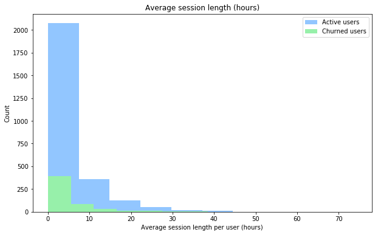

```
Average session length for churned users (hours):
+-------------------+
|avg(session_length)|
+-------------------+
|  4.718692338992486|
+-------------------+

Average session length for active users (hours):
+-------------------+
|avg(session_length)|
+-------------------+
|  5.047589365434434|
+-------------------+
```

```python
# average session length per user
# udf to convert time to correct format and show time difference in hours
# source: https://stackoverflow.com/questions/30283415/calculating-duration-by-subtracting-two-datetime-columns-in-string-format
time_delta = udf(lambda y, x: (datetime.datetime.strptime(y, '%Y-%m-%d %H:%M:%S') -
                               datetime.datetime.strptime(x, '%Y-%m-%d %H:%M:%S')).total_seconds()/3600)

# create dataframe with first timestamp (ts) per session
# add column 'churn' and set as 1 for rows with churned user
df_min = df_clean.groupBy('userId', 'sessionId').agg(min('ts').alias('min_ts'))
df_min = df_min.withColumn('churn', when((df_min.userId).isin(churned_users), 1).otherwise(0))

# create dataframe with last timestamp (ts) per session
df_max = df_clean.groupBy('userId', 'sessionId').agg(max('ts').alias('max_ts'))

# join dataframes
df_ts = df_min.join(df_max, on=['userId', 'sessionId'])

# apply udf when calculating and creating new column with time difference
df_ts = df_ts.withColumn('session_length', time_delta(df_ts['max_ts'], df_ts['min_ts']).cast('float'))

# graph of session length per user group
# store columns to be used as pandas dataframe
df_ts_pd = df_ts.select('churn', 'session_length').toPandas()

# plot results
plt.figure(figsize=(10,6))
plt.hist(df_ts_pd['session_length'][df_ts_pd['churn'] == 0], label='Active users')
plt.hist(df_ts_pd['session_length'][df_ts_pd['churn'] == 1], label='Churned users')
plt.legend(loc='upper right')
plt.title('Average session length (hours)')
plt.xlabel('Average session length per user (hours)')
plt.ylabel('Count')
plt.show()

print('')

# average session length for churned users
print('Average session length for churned users (hours):')
df_ts.where(col('churn') == 1).agg(avg('session_length')).show()

# average session length for active users
print('Average session length for active users (hours):')
df_ts.where(col('churn') == 0).agg(avg('session_length')).show()
```

**The average length of a session is slightly longer for active than churned users, and it seems active users spend more time on the platform each time they're using it.**

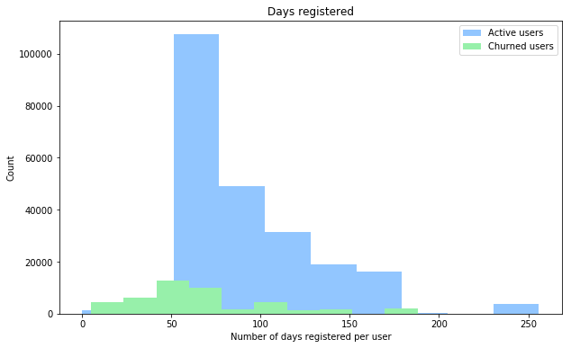

```
Average number of days registered for churned users:
+--------------------+
|avg(days_registered)|
+--------------------+
|   67.64847093437946|
+--------------------+

Average number of days registered for active users:
+--------------------+
|avg(days_registered)|
+--------------------+
|   92.97668995670625|
+--------------------+
```

```python
# average registration/usage length per user (days from registration date to ts for latest event)
# create dataframe with last timestamp (ts) per user
df_last = df_clean.groupBy('userId').agg(max('ts').alias('last_interaction'))

# join dataframes and add column 'days_registered' with number of days from registration date to ts for last event
df_reg = df_last.join(df_clean, on='userId').select(
    df_last['*'], df_clean['registration'], df_clean['churn']).withColumn(
    'days_registered', datediff(df_last['last_interaction'], df_clean['registration']))

# graph of number of days registered per user group
# store columns to be used as pandas dataframe
df_reg_pd = df_reg.select('churn', 'days_registered').toPandas()

# plot results
plt.figure(figsize=(10,6))
plt.hist(df_reg_pd['days_registered'][df_reg_pd['churn'] == 0], label='Active users')
plt.hist(df_reg_pd['days_registered'][df_reg_pd['churn'] == 1], label='Churned users')
plt.legend(loc='upper right')
plt.title('Days registered')
plt.xlabel('Number of days registered per user')
plt.ylabel('Count')
plt.show()

print('')

# get average number of days registered for churned users
print('Average number of days registered for churned users:')
df_reg.where(col('churn') == 1).agg(avg('days_registered')).show()

# get average number of days registered for active users
print('Average number of days registered for active users:')
df_reg.where(col('churn') == 0).agg(avg('days_registered')).show()
```

**Active users have, on average, been registered on the platform for a longer time than churned users.**

```python
# average number of unique artists played per user
print('Average number of unique artists played per churned user: {:.0f}'.format(
    df_clean.where(col('churn') == 1).groupBy('artist').count().count() / df_clean.where(
    col('churn') == 1).groupBy('userId').count().count()))

print('Average number of unique artists played per active user: {:.0f}'.format(
    df_clean.where(col('churn') == 0).groupBy('artist').count().count() / df_clean.where(
    col('churn') == 0).groupBy('userId').count().count()))

print('')

# average number of unique songs played per user
print('Average number of unique songs played per churned user: {:.0f}'.format(
    df_clean.where(col('churn') == 1).groupBy('song').count().count() / df_clean.where(
    col('churn') == 1).groupBy('userId').count().count()))

print('Average number of unique songs played per active user: {:.0f}'.format(
    df_clean.where(col('churn') == 0).groupBy('song').count().count() / df_clean.where(
    col('churn') == 0).groupBy('userId').count().count()))
```

```
Average number of unique artists played per churned user: 162
Average number of unique artists played per active user: 96

Average number of unique songs played per churned user: 370
Average number of unique songs played per active user: 308
```

```python
# average number of unique artists played per session
print('Average number of unique artists played per session for churned users: {:.0f}'.format(
    df_clean.where(col('churn') == 1).groupBy('artist').count().count() / df_clean.where(
    col('churn') == 1).groupBy('userId', 'sessionId').count().count()))

print('Average number of unique artists played per session for active users: {:.0f}'.format(
    df_clean.where(col('churn') == 0).groupBy('artist').count().count() / df_clean.where(
    col('churn') == 0).groupBy('userId', 'sessionId').count().count()))

print('')

# average number of unique songs played per session
print('Average number of unique songs played per session for churned users: {:.0f}'.format(
    df_clean.where(col('churn') == 1).groupBy('song').count().count() / df_clean.where(
    col('churn') == 1).groupBy('userId', 'sessionId').count().count()))

print('Average number of unique songs played per session for active users: {:.0f}'.format(
    df_clean.where(col('churn') == 0).groupBy('song').count().count() / df_clean.where(
    col('churn') == 0).groupBy('userId', 'sessionId').count().count()))
```

```
Average number of unique artists played per session for churned users: 16
Average number of unique artists played per session for active users: 6

Average number of unique songs played per session for churned users: 36
Average number of unique songs played per session for active users: 20
```

**Interestingly, churned users have, on average, listened to a higher number of both unique artists and songs compared to active users, both in total and per session. So while they haven't been more active in any other ways that we've looked at so far, they seem to be more active in terms of how many different artists and songs they listen to.**

```python
# percent paid and free plans of churned users
print('Share of churned users that are on a paid plan: {:.0f}%'.format(
    df_clean.where((df_clean.level == 'paid') & (df_clean.churn == 1)).groupBy('userId').count().count() /
    df_clean.where(df_clean.churn == 1).groupBy('userId', 'level').count().count() * 100))

print('Share of churned users that are on a free plan: {:.0f}%'.format(
    df_clean.where((df_clean.level == 'free') & (df_clean.churn == 1)).groupBy('userId').count().count() /
    df_clean.where(df_clean.churn == 1).groupBy('userId', 'level').count().count() * 100))

print('')

# percent paid and free plans of active users
print('Share of active users that are on a paid plan: {:.0f}%'.format(
    df_clean.where((df_clean.level == 'paid') & (df_clean.churn == 0)).groupBy('userId').count().count() /
    df_clean.where(df_clean.churn == 0).groupBy('userId', 'level').count().count() * 100))

print('Share of active users that are on a free plan: {:.0f}%'.format(
    df_clean.where((df_clean.level == 'free') & (df_clean.churn == 0)).groupBy('userId').count().count() /
    df_clean.where(df_clean.churn == 0).groupBy('userId', 'level').count().count() * 100))
```

```
Share of churned users that are on a paid plan: 44%
Share of churned users that are on a free plan: 56%

Share of active users that are on a paid plan: 46%
Share of active users that are on a free plan: 54%
```

**The share of users that are on paid or free plans are quite similar between churned and active users. Relatively speaking, churned users are slightly more on free plans and the distribution between free and paid plans is more even in the group with active users.**

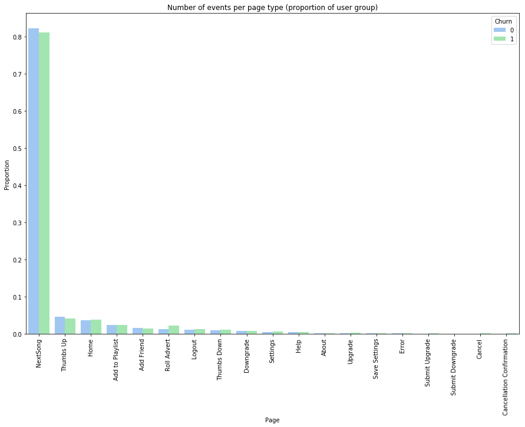

```
Number of events per page type for all events with a churned user:
+--------------------+-----+
|                page|count|
+--------------------+-----+
|            NextSong|36394|
|           Thumbs Up| 1859|
|                Home| 1672|
|     Add to Playlist| 1038|
|         Roll Advert|  967|
|          Add Friend|  636|
|              Logout|  553|
|         Thumbs Down|  496|
|           Downgrade|  337|
|            Settings|  270|
|                Help|  239|
|             Upgrade|  112|
|       Save Settings|   58|
|               About|   56|
|              Cancel|   52|
|Cancellation Conf...|   52|
|               Error|   32|
|      Submit Upgrade|   32|
|    Submit Downgrade|    9|
+--------------------+-----+

Number of events per page type for all events with active users:
+----------------+------+
|            page| count|
+----------------+------+
|        NextSong|191714|
|       Thumbs Up| 10692|
|            Home|  8410|
| Add to Playlist|  5488|
|      Add Friend|  3641|
|     Roll Advert|  2966|
|          Logout|  2673|
|     Thumbs Down|  2050|
|       Downgrade|  1718|
|        Settings|  1244|
|            Help|  1215|
|           About|   439|
|         Upgrade|   387|
|   Save Settings|   252|
|           Error|   220|
|  Submit Upgrade|   127|
|Submit Downgrade|    54|
+----------------+------+
```

```python
# graph of number of events per page type per user group
# plot results as proportions instead of counts
# source: https://stackoverflow.com/questions/35692781/python-plotting-percentage-in-seaborn-bar-plot
plt.figure(figsize=(15,10))

df_page_pd = df_clean.select('churn', 'page').toPandas()
x, y, hue = 'page', 'proportion', 'churn'
hue_order = ['Active users', 'Churned users']

(df_page_pd[x]
 .groupby(df_page_pd[hue])
 .value_counts(normalize=True)
 .rename(y)
 .reset_index()
 .pipe((sns.barplot, 'data'), x=x, y=y, hue=hue))

plt.legend(loc='upper right', title='Churn')
plt.title('Number of events per page type (proportion of user group)')
plt.xlabel('Page')
plt.ylabel('Proportion')
plt.xticks(rotation=90)
plt.show()

print('')

print('Number of events per page type for all events with a churned user:')
df_clean.where(col('churn') == 1).groupBy('page').count().sort(desc('count')).show()

print('Number of events per page type for all events with active users:')
df_clean.where(col('churn') == 0).groupBy('page').count().sort(desc('count')).show()
```

**The most frequent page types for all events by churned and active users is pretty similar, the top 4 are in the same frequency order for both: 'NextSong', 'Thumbs Up', 'Home' and 'Add to Playlist'. More than 80% of the dataset for both churned and active users is events with page type 'NextSong', which relates to listening to music.**

**The pages 'NextSong', 'Thumbs Up', 'Home', 'Add Friend', 'Roll Advert', 'Logout', 'Thumbs Down', 'Settings' and 'Upgrade' all have some difference in proportion between churned and active users for all events. We should look into these on a unique user basis as well.**

```python
# average number of songes played for churned and active users
print('Average number of songs played for churned users: {:.0f}'.format(
    df_clean.where((df_clean.page == 'NextSong') & (df_clean.churn == 1)).count() /
    df_clean.where(df_clean.churn == 1).groupBy('userId').count().count()))

print('Average number of songs played for active users: {:.0f}'.format(
    df_clean.where((df_clean.page == 'NextSong') & (df_clean.churn == 0)).count() /
    df_clean.where(df_clean.churn == 0).groupBy('userId').count().count()))
```

```
Average number of songs played for churned users: 700
Average number of songs played for active users: 1108
```

```python
# average number of thumbs up for churned and active users
print('Average number of thumbs up for churned users: {:.0f}'.format(
    df_clean.where((df_clean.page == 'Thumbs Up') & (df_clean.churn == 1)).count() /
    df_clean.where(df_clean.churn == 1).groupBy('userId').count().count()))

print('Average number of thumbs up for active users: {:.0f}'.format(
    df_clean.where((df_clean.page == 'Thumbs Up') & (df_clean.churn == 0)).count() /
    df_clean.where(df_clean.churn == 0).groupBy('userId').count().count()))
```

```
Average number of thumbs up for churned users: 36
Average number of thumbs up for active users: 62
```

```python
# average number of home page visits for churned and active users
print('Average number of home page visits for churned users: {:.0f}'.format(
    df_clean.where((df_clean.page == 'Home') & (df_clean.churn == 1)).count() /
    df_clean.where(df_clean.churn == 1).groupBy('userId').count().count()))

print('Average number of home page visits for active users: {:.0f}'.format(
    df_clean.where((df_clean.page == 'Home') & (df_clean.churn == 0)).count() /
    df_clean.where(df_clean.churn == 0).groupBy('userId').count().count()))
```

```
Average number of home page visits for churned users: 32
Average number of home page visits for active users: 49
```

```python
# average number of added friends for churned and active users
print('Average number of added friends for churned users: {:.0f}'.format(
    df_clean.where((df_clean.page == 'Add Friend') & (df_clean.churn == 1)).count() /
    df_clean.where(df_clean.churn == 1).groupBy('userId').count().count()))

print('Average number of added friends for active users: {:.0f}'.format(
    df_clean.where((df_clean.page == 'Add Friend') & (df_clean.churn == 0)).count() /
    df_clean.where(df_clean.churn == 0).groupBy('userId').count().count()))
```

```
Average number of added friends for churned users: 12
Average number of added friends for active users: 21
```

**On average, active users listen to more songs, give more thumbs up, visit the home page more (probably because this might be the first page you receive before or just after you log in) and add more friends.**

```python
# average number of ads received for churned and active users
print('Average number of ads received for churned users: {:.0f}'.format(
    df_clean.where((df_clean.page == 'Roll Advert') & (df_clean.churn == 1)).count() /
    df_clean.where(df_clean.churn == 1).groupBy('userId').count().count()))

print('Average number of ads received for active users: {:.0f}'.format(
    df_clean.where((df_clean.page == 'Roll Advert') & (df_clean.churn == 0)).count() /
    df_clean.where(df_clean.churn == 0).groupBy('userId').count().count()))
```

```
Average number of ads received for churned users: 19
Average number of ads received for active users: 17
```

**There is not a great difference in the number of ads received for churned and active users, churned users have received a few more on average. This variable might still be interesting though since we could see earlier that a fair amount of churned users received an ad before cancelling their account.**

```python
# average number of logouts for churned and active users
print('Average number of logouts for churned users: {:.0f}'.format(
    df_clean.where((df_clean.page == 'Logout') & (df_clean.churn == 1)).count() /
    df_clean.where(df_clean.churn == 1).groupBy('userId').count().count()))

print('Average number of logouts for active users: {:.0f}'.format(
    df_clean.where((df_clean.page == 'Logout') & (df_clean.churn == 0)).count() /
    df_clean.where(df_clean.churn == 0).groupBy('userId').count().count()))
```

```
Average number of logouts for churned users: 11
Average number of logouts for active users: 15
```

```python
# average number of thumbs down for churned and active users
print('Average number of thumbs down for churned users: {:.0f}'.format(
    df_clean.where((df_clean.page == 'Thumbs Down') & (df_clean.churn == 1)).count() /
    df_clean.where(df_clean.churn == 1).groupBy('userId').count().count()))

print('Average number of thumbs down for active users: {:.0f}'.format(
    df_clean.where((df_clean.page == 'Thumbs Down') & (df_clean.churn == 0)).count() /
    df_clean.where(df_clean.churn == 0).groupBy('userId').count().count()))
```

```
Average number of thumbs down for churned users: 10
Average number of thumbs down for active users: 12
```

```python
# average number of settings page visits for churned and active users
print('Average number of settings page visits for churned users: {:.0f}'.format(
    df_clean.where((df_clean.page == 'Settings') & (df_clean.churn == 1)).count() /
    df_clean.where(df_clean.churn == 1).groupBy('userId').count().count()))

print('Average number of settings page visits for active users: {:.0f}'.format(
    df_clean.where((df_clean.page == 'Settings') & (df_clean.churn == 0)).count() /
    df_clean.where(df_clean.churn == 0).groupBy('userId').count().count()))
```

```
Average number of settings page visits for churned users: 5
Average number of settings page visits for active users: 7
```

```python
# average number of plan upgrades for churned and active users
print('Average number of plan upgrades for churned users: {:.0f}'.format(
    df_clean.where((df_clean.page == 'Upgrade') & (df_clean.churn == 1)).count() /
    df_clean.where(df_clean.churn == 1).groupBy('userId').count().count()))

print('Average number of plan upgrades for active users: {:.0f}'.format(
    df_clean.where((df_clean.page == 'Upgrade') & (df_clean.churn == 0)).count() /
    df_clean.where(df_clean.churn == 0).groupBy('userId').count().count()))
```

```
Average number of plan upgrades for churned users: 2
Average number of plan upgrades for active users: 2
```

```python
# number of females in dataset
print('Number of female users in dataset: {:.0f}'.format(
df_clean.where(df_clean.gender == 'F').groupBy('userId').count().count()))

# number of males in dataset
print('Number of male users in dataset: {:.0f}'.format(
df_clean.where(df_clean.gender == 'M').groupBy('userId').count().count()))
```

```
Number of female users in dataset: 104
Number of male users in dataset: 121
```

```python
# percent female of all events
print('Percentage of all events that where made by females: {:.0f}%'.format(
df_clean.where(df_clean.gender == 'F').count() / df_clean.count() * 100))

# percent male of all events
print('Percentage of all events that where made by males: {:.0f}%'.format(
df_clean.where(df_clean.gender == 'M').count() / df_clean.count() * 100))
```

```
Percentage of all events that where made by females: 56%
Percentage of all events that where made by males: 44%
```

**There are more male than female users in the dataset. If we look at total events, a majority of them were made by females. So there are fewer females in the dataset but they appear to be more active.**

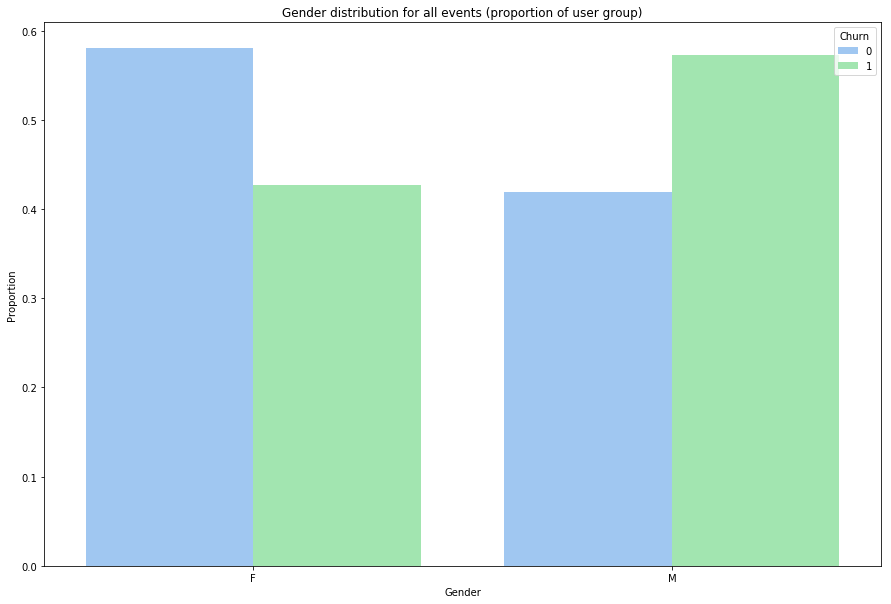

```
Share of churned users that are male: 62%
Share of churned users that are female: 38%

Share of active users that are male: 51%
Share of active users that are female: 49%
```

```python
# graph of gender proportion for all events per user group
plt.figure(figsize=(15,10))

df_gender_pd = df_clean.select('churn', 'gender').toPandas()
x, y, hue = 'gender', 'proportion', 'churn'
hue_order = ['Active users', 'Churned users']

(df_gender_pd[x]
 .groupby(df_gender_pd[hue])
 .value_counts(normalize=True)
 .rename(y)
 .reset_index()
 .pipe((sns.barplot, 'data'), x=x, y=y, hue=hue))

plt.legend(loc='upper right', title='Churn')
plt.title('Gender distribution for all events (proportion of user group)')
plt.xlabel('Gender')
plt.ylabel('Proportion')
plt.show()

print('')

# percent males and females of churned users
print('Share of churned users that are male: {:.0f}%'.format(
    df_clean.where((df_clean.gender == 'M') & (df_clean.churn == 1)).groupBy('userId').count().count() /
    df_clean.where(df_clean.churn == 1).groupBy('userId', 'gender').count().count() * 100))

print('Share of churned users that are female: {:.0f}%'.format(
    df_clean.where((df_clean.gender == 'F') & (df_clean.churn == 1)).groupBy('userId').count().count() /
    df_clean.where(df_clean.churn == 1).groupBy('userId', 'gender').count().count() * 100))

print('')

# percent males and females of active users
print('Share of active users that are male: {:.0f}%'.format(
    df_clean.where((df_clean.gender == 'M') & (df_clean.churn == 0)).groupBy('userId').count().count() /
    df_clean.where(df_clean.churn == 0).groupBy('userId', 'gender').count().count() * 100))

print('Share of active users that are female: {:.0f}%'.format(
    df_clean.where((df_clean.gender == 'F') & (df_clean.churn == 0)).groupBy('userId').count().count() /
    df_clean.where(df_clean.churn == 0).groupBy('userId', 'gender').count().count() * 100))
```

**There seems to be a difference in terms of gender between churned and active users when it comes to all events, a bigger proportion of males are churned users and a bigger proportion of females are active users. When we look at unique users, the gender distribution for active users is pretty even between the genders, but a majority of the churned users are male.**

```python
# percent churned and active of all females
print('Share of females that are churned users: {:.0f}%'.format(
    df_clean.where((df_clean.gender == 'F') & (df_clean.churn == 1)).groupBy('userId').count().count() /
    df_clean.where(df_clean.gender == 'F').groupBy('userId').count().count() * 100))

print('Share of females that are active users: {:.0f}%'.format(
    df_clean.where((df_clean.gender == 'F') & (df_clean.churn == 0)).groupBy('userId').count().count() /
    df_clean.where(df_clean.gender == 'F').groupBy('userId').count().count() * 100))

print('')

# percent churned and active of all males
print('Share of males that are churned users: {:.0f}%'.format(
    df_clean.where((df_clean.gender == 'M') & (df_clean.churn == 1)).groupBy('userId').count().count() /
    df_clean.where(df_clean.gender == 'M').groupBy('userId').count().count() * 100))

print('Share of males that are active users: {:.0f}%'.format(
    df_clean.where((df_clean.gender == 'M') & (df_clean.churn == 0)).groupBy('userId').count().count() /
    df_clean.where(df_clean.gender == 'M').groupBy('userId').count().count() * 100))
```

```
Share of females that are churned users: 19%
Share of females that are active users: 81%

Share of males that are churned users: 26%
Share of males that are active users: 74%
```

**Above we can see the share of churned and active users for all females and males. There is a greater share of all females that are active and a greater share of males that have churned relative to the proportions for females.**

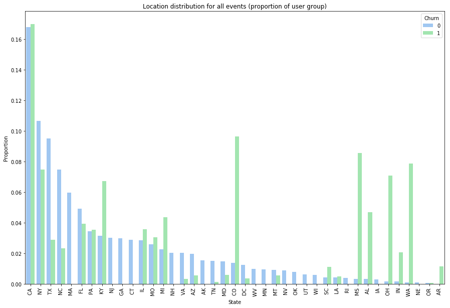

```
States for all events with a churned user:
+-----+-----+
|state|count|
+-----+-----+
|   CA| 7613|
|   CO| 4317|
|   MS| 3839|
|   WA| 3526|
|   NY| 3356|
|   OH| 3173|
|   KY| 3016|
|   AL| 2102|
|   MI| 1958|
|   FL| 1763|
|   IL| 1603|
|   PA| 1580|
|   MO| 1361|
|   TX| 1294|
|   NC| 1050|
|   IN|  918|
|   AR|  520|
|   SC|  494|
|   MD|  268|
|   MT|  254|
|   AZ|  251|
|   LA|  216|
|   DC|  158|
|   VA|  149|
|   TN|   62|
|   OR|   23|
+-----+-----+

States for all events with an active user:
+-----+-----+
|state|count|
+-----+-----+
|   CA|39158|
|   NY|24864|
|   TX|22200|
|   NC|17418|
```

[output cut: 22 more lines]

```
|   OK| 1842|
|   UT| 1419|
|   WI| 1342|
|   SC| 1011|
|   LA|  955|
|   RI|  927|
|   MS|  795|
|   AL|  755|
|   IA|  651|
|   OH|  347|
|   IN|  344|
|   WA|  246|
|   NE|  187|
|   OR|  119|
+-----+-----+
```

```python
# graph of location distribution for all events per user group
plt.figure(figsize=(15,10))

df_location_pd = df_clean.select('churn', 'state').toPandas()
x, y, hue = 'state', 'proportion', 'churn'
hue_order = ['Active users', 'Churned users']

(df_location_pd[x]
 .groupby(df_location_pd[hue])
 .value_counts(normalize=True)
 .rename(y)
 .reset_index()
 .pipe((sns.barplot, 'data'), x=x, y=y, hue=hue))

plt.legend(loc='upper right', title='Churn')
plt.title('Location distribution for all events (proportion of user group)')
plt.xlabel('State')
plt.ylabel('Proportion')
plt.xticks(rotation=90)
plt.show()

print('')

print('States for all events with a churned user:')
df_clean.where(col('churn') == 1).groupBy('state').count().sort(desc('count')).show(40)

print('States for all events with an active user:')
df_clean.where(col('churn') == 0).groupBy('state').count().sort(desc('count')).show(40)
```

# Feature Engineering

Once you've familiarized yourself with the data, build out the features you find promising to train your model on. To work with the full dataset, you can follow the following steps.

- Write a script to extract the necessary features from the smaller subset of data
- Ensure that your script is scalable, using the best practices discussed in Lesson 3
- Try your script on the full data set, debugging your script if necessary

If you are working in the classroom workspace, you can just extract features based on the small subset of data contained here. Be sure to transfer over this work to the larger dataset when you work on your Spark cluster.

**These variables appear to have a great enough difference between churned and active users to be interesting to include in a model to predict customer churn:**

- **Number of events per user**
- **Number of sessions per user**
- **Average session length per user**
- **Number of days registered per user**
- **Number of unique artists played per user**
- **Number of unique songs played to per user**
- **Number of 'page = NextSong' counts per user**
- **Number of 'page = Thumbs Up' counts per user**
- **Number of 'page = Home' counts per user**
- **Number of 'page = Add Friend' counts per user**
- **Number of 'page = Roll Advert' counts per user**
- **Gender**
- **State**

**Lets calculate and add the columns above to dataset to check more in depth if these are useful in modeling:**

```python
# calculate and add new columns

# create partitions
w1 = Window.partitionBy('userId')
w2 = Window.partitionBy('userId', 'sessionId')
w3 = Window.partitionBy('userId', 'artist')
w4 = Window.partitionBy('userId', 'song')

# total_events - column with total number of events per user
# create dataframe with row counts per user
df_events = df_clean.select('userId', count('userId').over(w1).alias('total_events')).distinct()
df_events = df_events.select(col('userId').alias('userId1'), 'total_events')

# total_sessions - column with total number of sessions per user
# create dataframe with session counts per user
df_sessions = df_clean.select('userId', 'sessionId', count('userId').over(w2).alias('count')).distinct()
df_sessions = df_sessions.withColumn('total_sessions', count('sessionId').over(w1))
df_sessions = df_sessions.dropDuplicates(['userId'])
df_sessions = df_sessions.select(col('userId').alias('userId2'), 'total_sessions')

# min_ts_session and max_ts_session - columns with timestamp from first and latest event per user and session
# session_length - column with session length in hours per session
# avg_session_length - column with average session length per user
# udf to convert time to correct format and show time difference in hours
time_delta = udf(lambda y, x: (datetime.datetime.strptime(y, '%Y-%m-%d %H:%M:%S') -
                                   datetime.datetime.strptime(x, '%Y-%m-%d %H:%M:%S')).total_seconds()/3600)

# create columns with timestamp (ts) from first and latest event per user and session
df_clean = df_clean.withColumn('min_ts_session', min('ts').over(w2))
df_clean = df_clean.withColumn('max_ts_session', max('ts').over(w2))

# apply udf when creating column with time difference (in hours)
df_clean = df_clean.withColumn('session_length', time_delta(df_clean['max_ts_session'],
                                                            df_clean['min_ts_session']).cast('float'))

# create column with average session length per user (in hours)
df_clean = df_clean.withColumn('avg_session_length', avg('session_length').over(w1))

# latest_ts and days_registered - columns with timestamp from latest event and with number of days registered
# create column with timestamp (ts) from latest event per user
df_clean = df_clean.withColumn('latest_ts', max('ts').over(w1))

# create column 'days_registered'
df_clean = df_clean.withColumn('days_registered', datediff(df_clean['latest_ts'], df_clean['registration']))

# unique_artists - column with number of unique artists played per user
# create dataframe with artist counts per user
df_artist = df_clean.select('userId', 'artist', count('userId').over(w3).alias('count')).distinct()
df_artist = df_artist.withColumn('unique_artists', count('artist').over(w1))
df_artist = df_artist.dropDuplicates(['userId'])
df_artist = df_artist.select(col('userId').alias('userId3'), 'unique_artists')

# unique_songs - column with number of unique songs played per user
# create dataframe with song counts per user
df_song = df_clean.select('userId', 'song', count('userId').over(w4).alias('count')).distinct()
df_song = df_song.withColumn('unique_songs', count('song').over(w1))
df_song = df_song.dropDuplicates(['userId'])
df_song = df_song.select(col('userId').alias('userId4'), 'unique_songs')

# total_nextsong - column with number of 'NextSong' events per user
# create dataframe with 'page = NextSong' counts per user
df_nextsong = df_clean.where(df_clean.page == 'NextSong').select(
    'userId', count('userId').over(w1).alias('total_nextsong')).distinct()
df_nextsong = df_nextsong.select(col('userId').alias('userId5'), 'total_nextsong')

# total_thumbsup - column with number of 'Thumbs Up' events per user
# create dataframe with 'page = Thumbs Up' counts per user
df_thumbsup = df_clean.where(df_clean.page == 'Thumbs Up').select(
    'userId', count('userId').over(w1).alias('total_thumbsup')).distinct()
df_thumbsup = df_thumbsup.select(col('userId').alias('userId6'), 'total_thumbsup')

# total_home - column with number of 'Home' events per user
# create dataframe with 'page = Home' counts per user
df_home = df_clean.where(df_clean.page == 'Home').select(
    'userId', count('userId').over(w1).alias('total_home')).distinct()
df_home = df_home.select(col('userId').alias('userId7'), 'total_home')

# total_addfriend - column with number of 'Add Friend' events per user
# create dataframe with 'page = Add Friend' counts per user
df_addfriend = df_clean.where(df_clean.page == 'Add Friend').select(
    'userId', count('userId').over(w1).alias('total_addfriend')).distinct()
df_addfriend = df_addfriend.select(col('userId').alias('userId8'), 'total_addfriend')

# total_rolladvert - column with number of 'Roll Advert' events per user
# create dataframe with 'page = Roll Advert' counts per user
df_rolladvert = df_clean.where(df_clean.page == 'Roll Advert').select(
    'userId', count('userId').over(w1).alias('total_rolladvert')).distinct()
df_rolladvert = df_rolladvert.select(col('userId').alias('userId9'), 'total_rolladvert')

# latest_event - column indicating row with latest event per user
df_clean = df_clean.withColumn('latest_event', when(df_clean.latest_ts == df_clean.ts, 1).otherwise(0))

# keep only row with latest event per user in data to be used for modeling
df_ml = df_clean.where(col('latest_event') == 1)

# drop duplicates from dataframe
df_ml = df_ml.dropDuplicates(['userId'])

# recode 'gender' to numerical binary
df_ml = df_ml.withColumn('gender', when(df_ml.gender == 'F', 1).otherwise(0))

# only keep columns to be used in modeling and replace NaN with 0
df_ml = df_ml.select('userId', 'churn', 'gender', 'state', 'avg_session_length',
                     'days_registered', ).fillna(0)

# add columns to df_ml and replace NaN with 0 for column
# add column 'total_events'
df_ml = df_ml.join(df_events, df_ml.userId == df_events.userId1, how='left').select(
    df_ml['*'], df_events['total_events']).fillna(0, subset=['total_events'])

# add column 'total_sessions'
df_ml = df_ml.join(df_sessions, df_ml.userId == df_sessions.userId2, how='left').select(
    df_ml['*'], df_sessions['total_sessions']).fillna(0, subset=['total_sessions'])

# add column 'unique_artists'
df_ml = df_ml.join(df_artist, df_ml.userId == df_artist.userId3, how='left').select(
    df_ml['*'], df_artist['unique_artists']).fillna(0, subset=['unique_artists'])

# add column 'unique_songs'
df_ml = df_ml.join(df_song, df_ml.userId == df_song.userId4, how='left').select(
    df_ml['*'], df_song['unique_songs']).fillna(0, subset=['unique_songs'])

# add column 'total_nextsong'
df_ml = df_ml.join(df_nextsong, df_ml.userId == df_nextsong.userId5, how='left').select(
    df_ml['*'], df_nextsong['total_nextsong']).fillna(0, subset=['total_nextsong'])

# add column 'total_thumbsup'
df_ml = df_ml.join(df_thumbsup, df_ml.userId == df_thumbsup.userId6, how='left').select(
    df_ml['*'], df_thumbsup['total_thumbsup']).fillna(0, subset=['total_thumbsup'])

# add column 'total_home'
df_ml = df_ml.join(df_home, df_ml.userId == df_home.userId7, how='left').select(
    df_ml['*'], df_home['total_home']).fillna(0, subset=['total_home'])

# add column 'total_addfriend'
df_ml = df_ml.join(df_addfriend, df_ml.userId == df_addfriend.userId8, how='left').select(
    df_ml['*'], df_addfriend['total_addfriend']).fillna(0, subset=['total_addfriend'])

# add column 'total_rolladvert'
df_ml = df_ml.join(df_rolladvert, df_ml.userId == df_rolladvert.userId9, how='left').select(
    df_ml['*'], df_rolladvert['total_rolladvert']).fillna(0, subset=['total_rolladvert'])
```

```python
df_ml.printSchema()
```

```
root
 |-- userId: string (nullable = true)
 |-- churn: integer (nullable = false)
 |-- gender: integer (nullable = false)
 |-- state: string (nullable = true)
 |-- avg_session_length: double (nullable = false)
 |-- days_registered: integer (nullable = true)
 |-- total_events: long (nullable = true)
 |-- total_sessions: long (nullable = true)
 |-- unique_artists: long (nullable = true)
 |-- unique_songs: long (nullable = true)
 |-- total_nextsong: long (nullable = true)
 |-- total_thumbsup: long (nullable = true)
 |-- total_home: long (nullable = true)
 |-- total_addfriend: long (nullable = true)
 |-- total_rolladvert: long (nullable = true)
```

```python
df_ml.cache()
```

```
DataFrame[userId: string, churn: int, gender: int, state: string, avg_session_length: double, days_registered: int, total_events: bigint, total_sessions: bigint, unique_artists: bigint, unique_songs: bigint, total_nextsong: bigint, total_thumbsup: bigint, total_home: bigint, total_addfriend: bigint,…
```

**Lets have a look at the new columns and how the distribution might differ between churned and active users:**

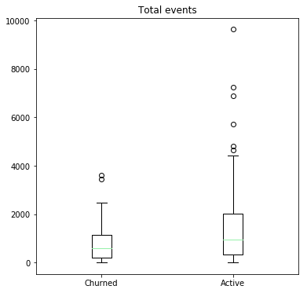

```
Basic statistics for churned users:
+-------+-----------------+
|summary|     total_events|
+-------+-----------------+
|  count|               52|
|   mean|862.7692307692307|
| stddev|852.2623782542744|
|    min|               11|
|    25%|              187|
|    50%|              552|
|    75%|             1102|
|    max|             3603|
+-------+-----------------+

Basic statistics for active users:
+-------+------------------+
|summary|      total_events|
+-------+------------------+
|  count|               173|
|   mean|1348.4971098265896|
| stddev| 1425.428636571019|
|    min|                 6|
|    25%|               321|
|    50%|               940|
|    75%|              2005|
|    max|              9632|
+-------+------------------+
```

```python
# plot total_events
# store column values as array
churn = df_ml.select('total_events').where(df_ml['churn'] == 1).toPandas().values.tolist()
active = df_ml.select('total_events').where(df_ml['churn'] == 0).toPandas().values.tolist()

# plot boxplots of both arrays in the same plot
data = [churn, active]
fig, ax = plt.subplots(figsize=(6,6))
ax.boxplot(data)
ax.set_xticklabels(['Churned', 'Active'])
plt.title('Total events')
plt.show()

# plot basic statistics
print('Basic statistics for churned users:')
df_ml.select('total_events').where(df_ml['churn'] == 1).summary().show()
print('Basic statistics for active users:')
df_ml.select('total_events').where(df_ml['churn'] == 0).summary().show()
```

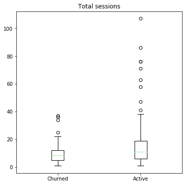

```
Basic statistics for churned users:
+-------+------------------+
|summary|    total_sessions|
+-------+------------------+
|  count|                52|
|   mean|10.326923076923077|
| stddev|  8.61080295917924|
|    min|                 1|
|    25%|                 5|
|    50%|                 8|
|    75%|                12|
|    max|                37|
+-------+------------------+

Basic statistics for active users:
+-------+------------------+
|summary|    total_sessions|
+-------+------------------+
|  count|               173|
|   mean|15.254335260115607|
| stddev|15.866963127421307|
|    min|                 1|
|    25%|                 6|
|    50%|                11|
|    75%|                19|
|    max|               107|
+-------+------------------+
```

```python
# plot total_sessions
# store column values as array
churn = df_ml.select('total_sessions').where(df_ml['churn'] == 1).toPandas().values.tolist()
active = df_ml.select('total_sessions').where(df_ml['churn'] == 0).toPandas().values.tolist()

# plot boxplots of both arrays in the same plot
data = [churn, active]
fig, ax = plt.subplots(figsize=(6,6))
ax.boxplot(data)
ax.set_xticklabels(['Churned', 'Active'])
plt.title('Total sessions')
plt.show()

# plot basic statistics
print('Basic statistics for churned users:')
df_ml.select('total_sessions').where(df_ml['churn'] == 1).summary().show()
print('Basic statistics for active users:')
df_ml.select('total_sessions').where(df_ml['churn'] == 0).summary().show()
```

**There is not that big of a difference in the total number of sessions if we compare churned and active users. The mean is higher for active users (likely because of the outliers for this group) but the number of sessions for 25%, 50% and 75% of the datasets don't differ that much.**

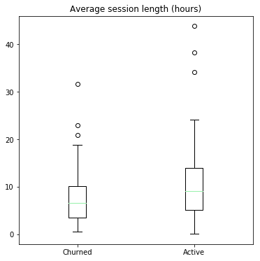

```
Basic statistics for churned users:
+-------+------------------+
|summary|avg_session_length|
+-------+------------------+
|  count|                52|
|   mean| 8.048868485300888|
| stddev| 6.345236883473346|
|    min|0.4927777647972107|
|    25%|3.3211112022399902|
|    50%|  6.38861172152296|
|    75%| 9.441156521151143|
|    max| 31.70917101300778|
+-------+------------------+

Basic statistics for active users:
+-------+-------------------+
|summary| avg_session_length|
+-------+-------------------+
|  count|                173|
|   mean| 10.080303650836603|
| stddev|  6.913496501718813|
|    min|0.11666666716337204|
|    25%|  5.094972980089402|
|    50%|    9.1002779006958|
|    75%| 13.971460027764826|
|    max|  43.79557182164721|
+-------+-------------------+
```

```python
# plot avg_session_length
# store column values as list
churn = df_ml.select('avg_session_length').where(df_ml['churn'] == 1).toPandas().values.tolist()
active = df_ml.select('avg_session_length').where(df_ml['churn'] == 0).toPandas().values.tolist()

# plot boxplots of both lists in the same plot
data = [churn, active]
fig, ax = plt.subplots(figsize=(6,6))
ax.boxplot(data)
ax.set_xticklabels(['Churned', 'Active'])
plt.title('Average session length (hours)')
plt.show()

# plot basic statistics
print('Basic statistics for churned users:')
df_ml.select('avg_session_length').where(df_ml['churn'] == 1).summary().show()
print('Basic statistics for active users:')
df_ml.select('avg_session_length').where(df_ml['churn'] == 0).summary().show()
```

**Average session length appears to be eavenly higher across the active users compared to churned users.**

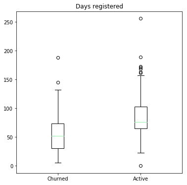

```
Basic statistics for churned users:
+-------+------------------+
|summary|   days_registered|
+-------+------------------+
|  count|                52|
|   mean| 57.36538461538461|
| stddev|36.587809416366895|
|    min|                 5|
|    25%|                29|
|    50%|                50|
|    75%|                73|
|    max|               188|
+-------+------------------+

Basic statistics for active users:
+-------+-----------------+
|summary|  days_registered|
+-------+-----------------+
|  count|              173|
|   mean|86.56647398843931|
| stddev|35.33432397636966|
|    min|                0|
|    25%|               65|
|    50%|               76|
|    75%|              103|
|    max|              256|
+-------+-----------------+
```

```python
# plot days_registered
# store column values as list
churn = df_ml.select('days_registered').where(df_ml['churn'] == 1).toPandas().values.tolist()
active = df_ml.select('days_registered').where(df_ml['churn'] == 0).toPandas().values.tolist()

# plot boxplots of both lists in the same plot
data = [churn, active]
fig, ax = plt.subplots(figsize=(6,6))
ax.boxplot(data)
ax.set_xticklabels(['Churned', 'Active'])
plt.title('Days registered')
plt.show()

# plot basic statistics
print('Basic statistics for churned users:')
df_ml.select('days_registered').where(df_ml['churn'] == 1).summary().show()
print('Basic statistics for active users:')
df_ml.select('days_registered').where(df_ml['churn'] == 0).summary().show()
```

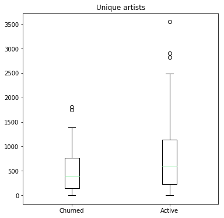

```
Basic statistics for churned users:
+-------+-----------------+
|summary|   unique_artists|
+-------+-----------------+
|  count|               52|
|   mean|518.6923076923077|
| stddev|455.9143167892335|
|    min|                8|
|    25%|              125|
|    50%|              374|
|    75%|              741|
|    max|             1804|
+-------+-----------------+

Basic statistics for active users:
+-------+-----------------+
|summary|   unique_artists|
+-------+-----------------+
|  count|              173|
|   mean|749.7861271676301|
| stddev| 633.235440098802|
|    min|                3|
|    25%|              226|
|    50%|              587|
|    75%|             1137|
|    max|             3544|
+-------+-----------------+
```

```python
# plot unique_artists
# store column values as list
churn = df_ml.select('unique_artists').where(df_ml['churn'] == 1).toPandas().values.tolist()
active = df_ml.select('unique_artists').where(df_ml['churn'] == 0).toPandas().values.tolist()

# plot boxplots of both lists in the same plot
data = [churn, active]
fig, ax = plt.subplots(figsize=(6,6))
ax.boxplot(data)
ax.set_xticklabels(['Churned', 'Active'])
plt.title('Unique artists')
plt.show()

# plot basic statistics
print('Basic statistics for churned users:')
df_ml.select('unique_artists').where(df_ml['churn'] == 1).summary().show()
print('Basic statistics for active users:')
df_ml.select('unique_artists').where(df_ml['churn'] == 0).summary().show()
```

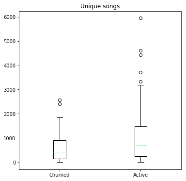

```
Basic statistics for churned users:
+-------+-----------------+
|summary|     unique_songs|
+-------+-----------------+
|  count|               52|
|   mean|638.3653846153846|
| stddev|619.5986692490094|
|    min|                8|
|    25%|              129|
|    50%|              412|
|    75%|              875|
|    max|             2562|
+-------+-----------------+

Basic statistics for active users:
+-------+-----------------+
|summary|     unique_songs|
+-------+-----------------+
|  count|              173|
|   mean|975.7687861271677|
| stddev|951.9128806124245|
|    min|                3|
|    25%|              239|
|    50%|              696|
|    75%|             1477|
|    max|             5946|
+-------+-----------------+
```

```python
# plot unique_songs
# store column values as list
churn = df_ml.select('unique_songs').where(df_ml['churn'] == 1).toPandas().values.tolist()
active = df_ml.select('unique_songs').where(df_ml['churn'] == 0).toPandas().values.tolist()

# plot boxplots of both lists in the same plot
data = [churn, active]
fig, ax = plt.subplots(figsize=(6,6))
ax.boxplot(data)
ax.set_xticklabels(['Churned', 'Active'])
plt.title('Unique songs')
plt.show()

# plot basic statistics
print('Basic statistics for churned users:')
df_ml.select('unique_songs').where(df_ml['churn'] == 1).summary().show()
print('Basic statistics for active users:')
df_ml.select('unique_songs').where(df_ml['churn'] == 0).summary().show()
```

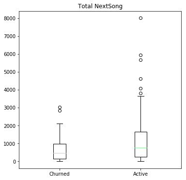

```
Basic statistics for churned users:
+-------+-----------------+
|summary|   total_nextsong|
+-------+-----------------+
|  count|               52|
|   mean|699.8846153846154|
| stddev|714.7376497666588|
|    min|                8|
|    25%|              133|
|    50%|              429|
|    75%|              927|
|    max|             3028|
+-------+-----------------+

Basic statistics for active users:
+-------+------------------+
|summary|    total_nextsong|
+-------+------------------+
|  count|               173|
|   mean|1108.1734104046243|
| stddev|1183.1467030410008|
|    min|                 3|
|    25%|               251|
|    50%|               747|
|    75%|              1640|
|    max|              8002|
+-------+------------------+
```

```python
# plot total_nextsong
# store column values as list
churn = df_ml.select('total_nextsong').where(df_ml['churn'] == 1).toPandas().values.tolist()
active = df_ml.select('total_nextsong').where(df_ml['churn'] == 0).toPandas().values.tolist()

# plot boxplots of both lists in the same plot
data = [churn, active]
fig, ax = plt.subplots(figsize=(6,6))
ax.boxplot(data)
ax.set_xticklabels(['Churned', 'Active'])
plt.title('Total NextSong')
plt.show()

# plot basic statistics
print('Basic statistics for churned users:')
df_ml.select('total_nextsong').where(df_ml['churn'] == 1).summary().show()
print('Basic statistics for active users:')
df_ml.select('total_nextsong').where(df_ml['churn'] == 0).summary().show()
```

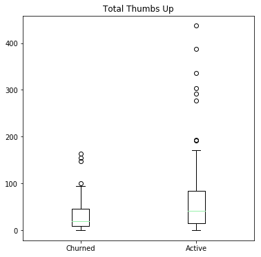

```
Basic statistics for churned users:
+-------+------------------+
|summary|    total_thumbsup|
+-------+------------------+
|  count|                52|
|   mean|             35.75|
| stddev|39.697816900513146|
|    min|                 0|
|    25%|                 8|
|    50%|                19|
|    75%|                45|
|    max|               163|
+-------+------------------+

Basic statistics for active users:
+-------+-----------------+
|summary|   total_thumbsup|
+-------+-----------------+
|  count|              173|
|   mean|61.80346820809248|
| stddev|70.41642406853158|
|    min|                0|
|    25%|               14|
|    50%|               41|
|    75%|               84|
|    max|              437|
+-------+-----------------+
```

```python
# plot total_thumbsup
# store column values as list
churn = df_ml.select('total_thumbsup').where(df_ml['churn'] == 1).toPandas().values.tolist()
active = df_ml.select('total_thumbsup').where(df_ml['churn'] == 0).toPandas().values.tolist()

# plot boxplots of both lists in the same plot
data = [churn, active]
fig, ax = plt.subplots(figsize=(6,6))
ax.boxplot(data)
ax.set_xticklabels(['Churned', 'Active'])
plt.title('Total Thumbs Up')
plt.show()

# plot basic statistics
print('Basic statistics for churned users:')
df_ml.select('total_thumbsup').where(df_ml['churn'] == 1).summary().show()
print('Basic statistics for active users:')
df_ml.select('total_thumbsup').where(df_ml['churn'] == 0).summary().show()
```

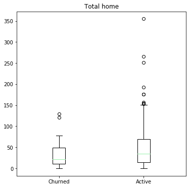

```
Basic statistics for churned users:
+-------+------------------+
|summary|        total_home|
+-------+------------------+
|  count|                52|
|   mean| 32.15384615384615|
| stddev|29.368106360328266|
|    min|                 0|
|    25%|                10|
|    50%|                21|
|    75%|                47|
|    max|               129|
+-------+------------------+

Basic statistics for active users:
+-------+-----------------+
|summary|       total_home|
+-------+-----------------+
|  count|              173|
|   mean|48.61271676300578|
| stddev|50.93618054493799|
|    min|                0|
|    25%|               14|
|    50%|               35|
|    75%|               69|
|    max|              355|
+-------+-----------------+
```

```python
# plot total_home
# store column values as list
churn = df_ml.select('total_home').where(df_ml['churn'] == 1).toPandas().values.tolist()
active = df_ml.select('total_home').where(df_ml['churn'] == 0).toPandas().values.tolist()

# plot boxplots of both lists in the same plot
data = [churn, active]
fig, ax = plt.subplots(figsize=(6,6))
ax.boxplot(data)
ax.set_xticklabels(['Churned', 'Active'])
plt.title('Total home')
plt.show()

# plot basic statistics
print('Basic statistics for churned users:')
df_ml.select('total_home').where(df_ml['churn'] == 1).summary().show()
print('Basic statistics for active users:')
df_ml.select('total_home').where(df_ml['churn'] == 0).summary().show()
```

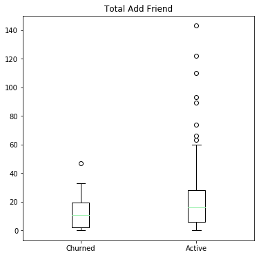

```
Basic statistics for churned users:
+-------+------------------+
|summary|   total_addfriend|
+-------+------------------+
|  count|                52|
|   mean| 12.23076923076923|
| stddev|11.157720240502051|
|    min|                 0|
|    25%|                 2|
|    50%|                10|
|    75%|                19|
|    max|                47|
+-------+------------------+

Basic statistics for active users:
+-------+------------------+
|summary|   total_addfriend|
+-------+------------------+
|  count|               173|
|   mean|21.046242774566473|
| stddev|22.286666946671954|
|    min|                 0|
|    25%|                 6|
|    50%|                16|
|    75%|                28|
|    max|               143|
+-------+------------------+
```

```python
# plot total_addfriend
# store column values as list
churn = df_ml.select('total_addfriend').where(df_ml['churn'] == 1).toPandas().values.tolist()
active = df_ml.select('total_addfriend').where(df_ml['churn'] == 0).toPandas().values.tolist()

# plot boxplots of both lists in the same plot
data = [churn, active]
fig, ax = plt.subplots(figsize=(6,6))
ax.boxplot(data)
ax.set_xticklabels(['Churned', 'Active'])
plt.title('Total Add Friend')
plt.show()

# plot basic statistics
print('Basic statistics for churned users:')
df_ml.select('total_addfriend').where(df_ml['churn'] == 1).summary().show()
print('Basic statistics for active users:')
df_ml.select('total_addfriend').where(df_ml['churn'] == 0).summary().show()
```

**There is not that big of a difference in the total number of added friends if we compare churned and active users. The mean is higher for active users, the same as for the column with total sessions, but the number of added friends for 25%, 50% and 75% of the datasets don't differ that much.**

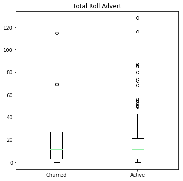

```
Basic statistics for churned users:
+-------+------------------+
|summary|  total_rolladvert|
+-------+------------------+
|  count|                52|
|   mean|18.596153846153847|
| stddev|21.799675852406267|
|    min|                 0|
|    25%|                 3|
|    50%|                11|
|    75%|                27|
|    max|               115|
+-------+------------------+

Basic statistics for active users:
+-------+------------------+
|summary|  total_rolladvert|
+-------+------------------+
|  count|               173|
|   mean| 17.14450867052023|
| stddev|21.527076957738625|
|    min|                 0|
|    25%|                 3|
|    50%|                11|
|    75%|                21|
|    max|               128|
+-------+------------------+
```

```python
# plot total_rolladvert
# store column values as list
churn = df_ml.select('total_rolladvert').where(df_ml['churn'] == 1).toPandas().values.tolist()
active = df_ml.select('total_rolladvert').where(df_ml['churn'] == 0).toPandas().values.tolist()

# plot boxplots of both lists in the same plot
data = [churn, active]
fig, ax = plt.subplots(figsize=(6,6))
ax.boxplot(data)
ax.set_xticklabels(['Churned', 'Active'])
plt.title('Total Roll Advert')
plt.show()

# plot basic statistics
print('Basic statistics for churned users:')
df_ml.select('total_rolladvert').where(df_ml['churn'] == 1).summary().show()
print('Basic statistics for active users:')
df_ml.select('total_rolladvert').where(df_ml['churn'] == 0).summary().show()
```

**Over all, we can see that the standard deviation is higher for active users, there is more variation in this data and also more outliers. This might be because we are comparing a relatively big dataset to a much smaller one or it could mean that active users actually have more variation in their behaviors. After looking at the outlier values, I have decided to keep them as is because they don't appear to be errors and they can add meaning to the model.**

**We sould also look att the correlation between the numerical variables in the dataset to see if some features seem to give the same information and possibly reomve some of them to make the model faster:**

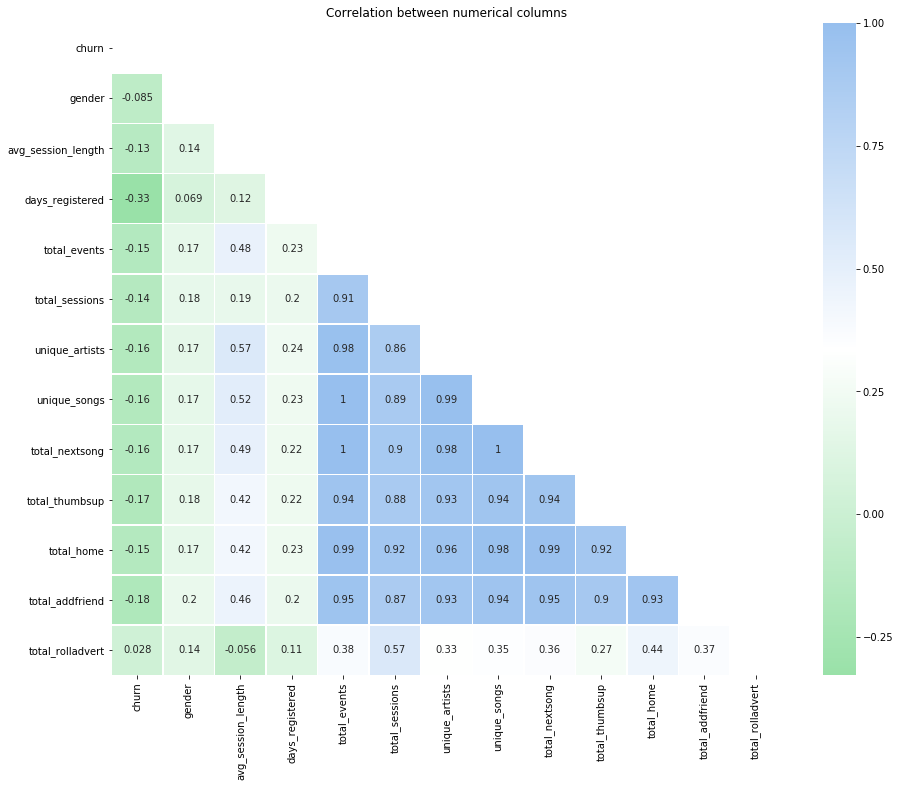

```python
# correlation matrix of numerical columns
# create correlation matrix
df_corr = df_ml.toPandas().corr()

plt.figure(figsize=(15,12))
plt.title('Correlation between numerical columns')

# create a mask for the upper triangle
mask = np.zeros_like(df_corr)
mask[np.triu_indices_from(mask)] = True

# create custom color range for heatmap to match other graphs in notebook
cmap = mcolors.LinearSegmentedColormap.from_list('n',['#99E1A8', '#FFFFFF','#97BFEE'])

sns.heatmap(df_corr, mask=mask, annot=True, linewidths=0.5, cmap=cmap)
plt.show()
```

**A lot of features seem to have a strong correlation. 'total_events' has a perfectly positive correlation with 'unique_songs' and 'total_nextsong, and 'unique_songs' has a perfectly positive correlaton with 'total_nextsong'.**

**Having too many features that are correlated among each other (not regarding the target variable) might just mean some of the features will not add any new information to the model and are therefore redundant. I might remove some of the features with high correlation if it seems to make the models more stable.**

**Before we can use the data for modeling we need to recode 'state', which is a categorical variable, into a binary column per state (one hot encoding). We also need to apply some scaling to normalize the range across the features., the MinMax scaler preserves the original data distribution.**

```python
# data modeling preparation pipeline

# list of numerical columns
numerical_cols = ['avg_session_length',
                  'days_registered',
                  'total_events',
                  'total_sessions',
                  'unique_artists',
                  'unique_songs',
                  'total_nextsong',
                  'total_thumbsup',
                  'total_home',
                  'total_addfriend',
                  'total_rolladvert']

# convert sting column to index column
indexer = StringIndexer(inputCol='state', outputCol='stateIndex', handleInvalid='keep')
inputs = [indexer.getOutputCol(), 'gender']
# one hot encode categorical columns to numerical vector columns
encoder = OneHotEncoderEstimator(inputCols=inputs, outputCols=['stateVec', 'genderVec'], handleInvalid='keep')
# transform numerical columns to a single vector column
num_assembler = VectorAssembler(inputCols=numerical_cols, outputCol='num_features')
# apply scaler (MinMax scaler preserves original data distribution)
scaler = MinMaxScaler(inputCol='num_features', outputCol='scaled_features')
# transform all create vector columns into one vector column
assembler = VectorAssembler(inputCols=['stateVec', 'genderVec', 'scaled_features'], outputCol='features')
# create pipeline with above steps
data_pipeline = Pipeline(stages=[indexer, encoder, num_assembler, scaler, assembler])
# fit dataframe to pipleine and transform
df_ml = data_pipeline.fit(df_ml).transform(df_ml)
```

```python
df_ml.toPandas().head(1)
```

|  | userId | churn | gender | state | avg_session_length | days_registered | total_events | total_sessions | unique_artists | unique_songs | total_nextsong | total_thumbsup | total_home | total_addfriend | total_rolladvert | stateIndex | stateVec | genderVec | num_features | scaled_features | features |
| --- | --- | --- | --- | --- | --- | --- | --- | --- | --- | --- | --- | --- | --- | --- | --- | --- | --- | --- | --- | --- | --- |
| 0 | 100010 | 0 | 1 | CT | 3.389725 | 55 | 381 | 7 | 252 | 269 | 275 | 17 | 11 | 4 | 52 | 8.0 | (0.0, 0.0, 0.0, 0.0, 0.0, 0.0, 0.0, 0.0, 1.0, 0.0, 0.0, 0.0, 0.0, 0.0, 0.0, 0.0, 0.0, 0.0, 0.0, 0.0, 0.0, 0.0, 0.0, 0.0, 0.0, 0.0, 0.0, 0.0, 0.0, 0.0, 0.0, 0.0, 0.0, 0.0, 0.0, 0.0, 0.0, 0.0, 0.0, 0.0,… | (0.0, 1.0) | [3.38972506858, 55.0, 381.0, 7.0, 252.0, 269.0, 275.0, 17.0, 11.0, 4.0, 52.0] | [0.074934533955, 0.21484375, 0.0389569914814, 0.0566037735849, 0.070319118893, 0.0447585394582, 0.0340042505313, 0.0389016018307, 0.030985915493, 0.027972027972, 0.40625] | (0.0, 0.0, 0.0, 0.0, 0.0, 0.0, 0.0, 0.0, 1.0, 0.0, 0.0, 0.0, 0.0, 0.0, 0.0, 0.0, 0.0, 0.0, 0.0, 0.0, 0.0, 0.0, 0.0, 0.0, 0.0, 0.0, 0.0, 0.0, 0.0, 0.0, 0.0, 0.0, 0.0, 0.0, 0.0, 0.0, 0.0, 0.0, 0.0, 0.0,… |

**The features column is now ready to be used for modeling.**

# Modeling

Split the full dataset into train, test, and validation sets. Test out several of the machine learning methods you learned. Evaluate the accuracy of the various models, tuning parameters as necessary. Determine your winning model based on test accuracy and report results on the validation set. Since the churned users are a fairly small subset, I suggest using F1 score as the metric to optimize.

```python
# split data into train, validation and test sets
train, validation_test = df_ml.randomSplit([0.7, 0.3], seed = 4)
validation, test = validation_test.randomSplit([0.5, 0.5], seed = 4)

# shape of datasets (spark random split doesn't guarantee a split exactly to the input weigths)
print('Shape of train, validation and test sets:')
print((train.count(), len(train.columns)))
print((validation.count(), len(validation.columns)))
print((test.count(), len(test.columns)))
```

```
Shape of train, validation and test sets:
(163, 21)
(11, 21)
(51, 21)
```

**As we can see the valdation and test set don't have a 50/50 split, this is due to how spark's randomsplit function divides the samples, it doesn't guarantee an exact split to the weights.**

```python
# set up and fit models to training data
# baseline results for each model without any hyperparameter tuning
# add timer to see how long it takes to train each model

# naive bayes
start1 = time()
nb = NaiveBayes(featuresCol='features', labelCol='churn')
nb_model = nb.fit(train)
end1 = time()

print('Total training time for naive bayes: {} seconds'.format(end1 - start1))

# logistic regression
start2 = time()
lr = LogisticRegression(featuresCol='features', labelCol='churn')
lr_model = lr.fit(train)
end2 = time()

print('Total training time for logic regression: {} seconds'.format(end2 - start2))

# linear svc (support vector machine)
start3 = time()
svc = LinearSVC(featuresCol='features', labelCol='churn')
svc_model = svc.fit(train)
end3 = time()

print('Total training time for linear svc: {} seconds'.format(end3 - start3))

# random forest
start4 = time()
rf = RandomForestClassifier(featuresCol='features', labelCol='churn', seed=4)
rf_model = rf.fit(train)
end4 = time()

print('Total training time for random forest: {} seconds'.format(end4 - start4))

# decision tree
start5 = time()
dt = DecisionTreeClassifier(featuresCol='features', labelCol='churn', seed=4)
dt_model = dt.fit(train)
end5 = time()

print('Total training time for decision tree: {} seconds'.format(end5 - start5))
```

```
Total training time for naive bayes: 9.472581148147583 seconds
Total training time for logic regression: 249.5936975479126 seconds
Total training time for linear svc: 1131.8211860656738 seconds
Total training time for random forest: 54.43535494804382 seconds
Total training time for decision tree: 32.28688311576843 seconds
```

**All models are first initiated to show their baseline results - how well they are able to predict on the validation set without any parameter tuning.**

**Naive bayes is the fastest model to train with our dataset and the linear SVC takes the longest.**

```python
# baseline model predictions
# create lists with the models and their respective names
models = [nb_model,
          lr_model,
          svc_model,
          rf_model,
          dt_model]

model_names = ['naive bayes',
               'logistic regression',
               'linear svc',
               'random forest',
               'decision tree']

# for all models, make prediction, calculate f1 scores and display results
for i in range(len(models)):
    model = models[i]
    model_name = model_names[i]
    # predict on validation set
    validation_prediction = model.transform(validation)
    # use MulticlassClassificationEvaluator to get f1 scores
    evaluator1 = MulticlassClassificationEvaluator(labelCol='churn')
    # use BinaryClassificationEvaluator to get area under PR
    evaluator2 = BinaryClassificationEvaluator(rawPredictionCol='prediction', labelCol='churn')
    # make evaluation and print f1-score and area under PR per model
    print('F1 score for {} on validation set: {}'.format((model_name), (evaluator1.evaluate(
        validation_prediction, {evaluator1.metricName:'f1'}))))

    print('Area under PR for {} on validation set: {}'.format((model_name), (evaluator2.evaluate(
        validation_prediction, {evaluator2.metricName:'areaUnderPR'}))))

    print('')
```

```
F1 score for naive bayes on validation set: 0.7363636363636363
Area under PR for naive bayes on validation set: 0.18181818181818182

F1 score for logistic regression on validation set: 0.7363636363636363
Area under PR for logistic regression on validation set: 0.18181818181818182

F1 score for linear svc on validation set: 0.7363636363636363
Area under PR for linear svc on validation set: 0.18181818181818182

F1 score for random forest on validation set: 0.7363636363636363
Area under PR for random forest on validation set: 0.18181818181818182

F1 score for decision tree on validation set: 0.8963317384370016
Area under PR for decision tree on validation set: 0.7954545454545454
```

**Since our dataset is imbalanced, we have chosen to use the f1 score as a performance metric, which is the harmonic mean of precision and recall. Measuring accuracy could lead to a poor model when the input data is imbalanced, the accuracy could be high because the model predicts well on the majority class (active users), but that would not be a good model for us since our goal is to predict on the minority class (churned users). Precision and recall calculations do not make use of the true negatives, they're only concerned with the correct prediction of the minority class.**

**The area under PR refers to the area under the precision-recall curve (AUC). Precision-recall curves are more informative than the receiver operating characteristic (ROC) curve when evaluating binary classifiers on an imbalanced dataset, and a precision-recall curve is a plot of the precision and the recall for different thresholds. The area under the curve (AUC) can be used as a summary of the model skill. Area under the PR curve will typically show larger differences than area under the ROC curve when comparing classifiers trained on imbalanced data.**

**It appears that the decision tree model perform the best on the validation set. As mentioned above, this model doesn't only follow a linear relationship, which might suggest that our input and output features have a non-linear relationship and hence this model will be more suited to the data.**

**Let's tune the decision tree model to see if we can improve it further.**

**Tune hyperparameters for decision tree model:**

```python
# get parameter options for decision tree model
dt.explainParams()
```

```
'cacheNodeIds: If false, the algorithm will pass trees to executors to match instances with nodes. If true, the algorithm will cache node IDs for each instance. Caching can speed up training of deeper trees. Users can set how often should the cache be checkpointed or disable it by setting checkpoint…
```

```python
# tune hyperparapeters with ParamGridBuilder and CrossValidator
# build paramGrid with hyperparameters to tune
paramGrid = (ParamGridBuilder()
            .addGrid(dt.impurity,['entropy', 'gini']) # default: gini
            .addGrid(dt.maxDepth, [5, 10, 15]) # default: 5
            .build())

# add paramGrid to CrossValidator
crossval = CrossValidator(estimator = dt,
                          estimatorParamMaps = paramGrid,
                          evaluator = MulticlassClassificationEvaluator(labelCol='churn'),
                          numFolds = 5)

# fit cv model
start7 = time()
cv_dt = crossval.fit(train)
end7 = time()

print('Total training time for hyperparameter tuning on decision tree model: {} seconds'.format(end7 - start7))
```

```
Total training time for hyperparameter tuning on decision tree model: 1239.4033126831055 seconds
```

**The hyperparameters I have chosen to test in tuning the decision tree model are 'impurity' and 'maxDepth'. The 'impurity' parameter with 'entropy' and 'gini' refers to which criterion to be used for information gain calculation and 'maxDepth' refers to the maximum depth of the tree.**

```python
# predict on validation set
validation_prediction_dt = cv_dt.transform(validation)

# make evaluation and print f1-score
print('F1 score for tuned decision tree model on validation set: {}'.format(evaluator1.evaluate(
    validation_prediction_dt, {evaluator1.metricName:'f1'})))
```

```
F1 score for tuned decision tree model on validation set: 0.8963317384370016
```

```python
# predict on test set
test_prediction_dt = cv_dt.transform(test)

# make evaluation and print f1-score
print('F1 score for tuned decision tree model on test set: {}'.format(evaluator1.evaluate(test_prediction_dt,
                                                                     {evaluator1.metricName:'f1'})))
```

```
F1 score for tuned decision tree model on test set: 0.8099323383728836
```

```python
# test baseline decision tree model on test set
# predict on test set
test_prediction_dt_baseline = dt_model.transform(test)

# make evaluation and print f1-score
print('F1 score for baseline decision tree model on test set: {}'.format(evaluator1.evaluate(
            test_prediction_dt_baseline, {evaluator1.metricName:'f1'})))
```

```
F1 score for baseline decision tree model on test set: 0.8099323383728836
```

**The tuned decision tree model performs exactly as well as the baseline decision tree model on both the validation and test sets and our hyperparameter tuning didn't improve the model. Maybe this is due to our model having so few examples to train on. We can see below that the best hyperparameter tuning for the model are the same as the default settings, which are the lowest alternatives of the different options we tested. Adding more hyperparameters to a model increases its complexity and depth, and since we have so few examples to train on this could easily lead to overfitting and that's proably why the best model options are the least complex for this model.**

**We should try the decision tree model on the bigger dataset to see if it gets the same results.**

```python
# get parameter options for best decision tree model
cv_dt.bestModel.extractParamMap()
```

```
{Param(parent='DecisionTreeClassifier_54e82d44df56', name='cacheNodeIds', doc='If false, the algorithm will pass trees to executors to match instances with nodes. If true, the algorithm will cache node IDs for each instance. Caching can speed up training of deeper trees.'): False,
 Param(parent='DecisionTreeClassifier_54e82d44df56', name='checkpointInterval', doc='set checkpoint interval (>= 1) or disable checkpoint (-1). E.g. 10 means that the cache will get checkpointed every 10 iterations. Note: this setting will be ignored if the checkpoint directory is not set in the Spa…
 Param(parent='DecisionTreeClassifier_54e82d44df56', name='featuresCol', doc='features column name'): 'features',
 Param(parent='DecisionTreeClassifier_54e82d44df56', name='impurity', doc='Criterion used for information gain calculation (case-insensitive). Supported options: entropy, gini'): 'gini',
 Param(parent='DecisionTreeClassifier_54e82d44df56', name='labelCol', doc='label column name'): 'churn',
 Param(parent='DecisionTreeClassifier_54e82d44df56', name='maxBins', doc='Max number of bins for discretizing continuous features.  Must be >=2 and >= number of categories for any categorical feature.'): 32,
 Param(parent='DecisionTreeClassifier_54e82d44df56', name='maxDepth', doc='Maximum depth of the tree. (>= 0) E.g., depth 0 means 1 leaf node; depth 1 means 1 internal node + 2 leaf nodes.'): 5,
 Param(parent='DecisionTreeClassifier_54e82d44df56', name='maxMemoryInMB', doc='Maximum memory in MB allocated to histogram aggregation.'): 256,
 Param(parent='DecisionTreeClassifier_54e82d44df56', name='minInfoGain', doc='Minimum information gain for a split to be considered at a tree node.'): 0.0,
 Param(parent='DecisionTreeClassifier_54e82d44df56', name='minInstancesPerNode', doc='Minimum number of instances each child must have after split.  If a split causes the left or right child to have fewer than minInstancesPerNode, the split will be discarded as invalid. Should be >= 1.'): 1,
 Param(parent='DecisionTreeClassifier_54e82d44df56', name='predictionCol', doc='prediction column name'): 'prediction',
 Param(parent='DecisionTreeClassifier_54e82d44df56', name='probabilityCol', doc='Column name for predicted class conditional probabilities. Note: Not all models output well-calibrated probability estimates! These probabilities should be treated as confidences, not precise probabilities'): 'probabili…
 Param(parent='DecisionTreeClassifier_54e82d44df56', name='rawPredictionCol', doc='raw prediction (a.k.a. confidence) column name'): 'rawPrediction',
 Param(parent='DecisionTreeClassifier_54e82d44df56', name='seed', doc='random seed'): 4}
```

**Best hyperparameters options for the decision tree model that we have tested:**

- **impurity: gini**
- **maxDepth: 5**

**Feature importance for tuned decision tree model:**

```python
# function to extract feature importance score and name for model, convert to pandas dataframe and
# add column with cumulative score
# source: https://www.timlrx.com/2018/06/19/feature-selection-using-feature-importance-
# score-creating-a-pyspark-estimator/

def extract_feature_imp(featureImp, dataset, featuresCol):
    # dictionary to replace vector name with feature name
    feat_name_dict = {
        'scaled_features_0': 'avg_session_length',
        'scaled_features_1': 'days_registered',
        'scaled_features_2': 'total_events',
        'scaled_features_3': 'total_sessions',
        'scaled_features_4': 'unique_artists',
        'scaled_features_5': 'unique_songs',
        'scaled_features_6': 'total_nextsong',
        'scaled_features_7': 'total_thumbsup',
        'scaled_features_8': 'total_home',
        'scaled_features_9': 'total_addfriend',
        'scaled_features_10': 'total_rolladvert',
        'stateVec_ CA': 'state: CA',
        'stateVec_ NY': 'state: NY',
        'stateVec_ TX': 'state: TX',
        'stateVec_ FL': 'state: FL',
        'stateVec_ NC': 'state: NC',
        'stateVec_ IL': 'state: IL',
        'stateVec_ PA': 'state: PA',
        'stateVec_ MO': 'state: MO',
        'stateVec_ CT': 'state: CT',
        'stateVec_ AZ': 'state: AZ',
        'stateVec_ GA': 'state: GA',
        'stateVec_ OH': 'state: OH',
        'stateVec_ MA': 'state: MA',
        'stateVec_ MI': 'state: MI',
        'stateVec_ DC': 'state: DC',
        'stateVec_ CO': 'state: CO',
        'stateVec_ AL': 'state: AL',
        'stateVec_ VA': 'state: VA',
        'stateVec_ KY': 'state: KY',
        'stateVec_ WA': 'state: WA',
        'stateVec_ OR': 'state: OR',
        'stateVec_ MS': 'state: MS',
        'stateVec_ SC': 'state: SC',
        'stateVec_ MN': 'state: MN',
        'stateVec_ IN': 'state: IN',
        'stateVec_ TN': 'state: TN',
        'stateVec_ MD': 'state: MD',
        'stateVec_ NV': 'state: NV',
        'stateVec_ RI': 'state: RI',
        'stateVec_ MT': 'state: MT',
        'stateVec_ NH': 'state: NH',
        'stateVec_ LA': 'state: LA',
        'stateVec_ UT': 'state: UT',
        'stateVec_ AK': 'state: AK',
        'stateVec_ NJ': 'state: NJ',
        'stateVec_ WI': 'state: WI',
        'stateVec_ WV': 'state: WV',
        'stateVec_ IA': 'state: IA',
        'stateVec_ OK': 'state: OK',
        'stateVec_ NE': 'state: NE',
        'stateVec_ AR': 'state: AR',
        'stateVec___unknown': 'state:__unknown',
        'genderVec_0': 'gender: male',
        'genderVec_1': 'gender: female'}

    list_extract = []

    for i in dataset.schema[featuresCol].metadata["ml_attr"]["attrs"]:
        list_extract = list_extract + dataset.schema[featuresCol].metadata["ml_attr"]["attrs"][i]

    # create pandas dataframe with index and feature vector name from metadata
    df = pd.DataFrame(list_extract)
    # add column with feature importance score
    df['score'] = df['idx'].apply(lambda x: featureImp[x])
    df = df.sort_values('score', ascending = False)
    # add column with cumulative feature importance score
    df['cumulative_score'] = df['score'].cumsum()
    # replace feature vector name with feature name
    df['name'] = df['name'].map(feat_name_dict)

    return df
```

```python
# get dataframe with feature importance
df_feat_imp_dt = extract_feature_imp(cv_dt.bestModel.featureImportances, df_ml, 'features')
df_feat_imp_dt.head(15)
```

|  | idx | name | score | cumulative_score |
| --- | --- | --- | --- | --- |
| 1 | 45 | days_registered | 0.278586 | 0.278586 |
| 10 | 54 | total_rolladvert | 0.153097 | 0.431684 |
| 3 | 47 | total_sessions | 0.113773 | 0.545456 |
| 0 | 44 | avg_session_length | 0.076237 | 0.621693 |
| 9 | 53 | total_addfriend | 0.072661 | 0.694355 |
| 2 | 46 | total_events | 0.059147 | 0.753501 |
| 32 | 21 | state: MS | 0.046887 | 0.800389 |
| 30 | 19 | state: WA | 0.045940 | 0.846329 |
| 28 | 17 | state: VA | 0.038400 | 0.884728 |
| 29 | 18 | state: KY | 0.038274 | 0.923003 |
| 38 | 27 | state: NV | 0.035882 | 0.958885 |
| 12 | 1 | state: NY | 0.020931 | 0.979816 |
| 11 | 0 | state: CA | 0.020184 | 1.000000 |
| 50 | 39 | state: NE | 0.000000 | 1.000000 |
| 40 | 29 | state: MT | 0.000000 | 1.000000 |

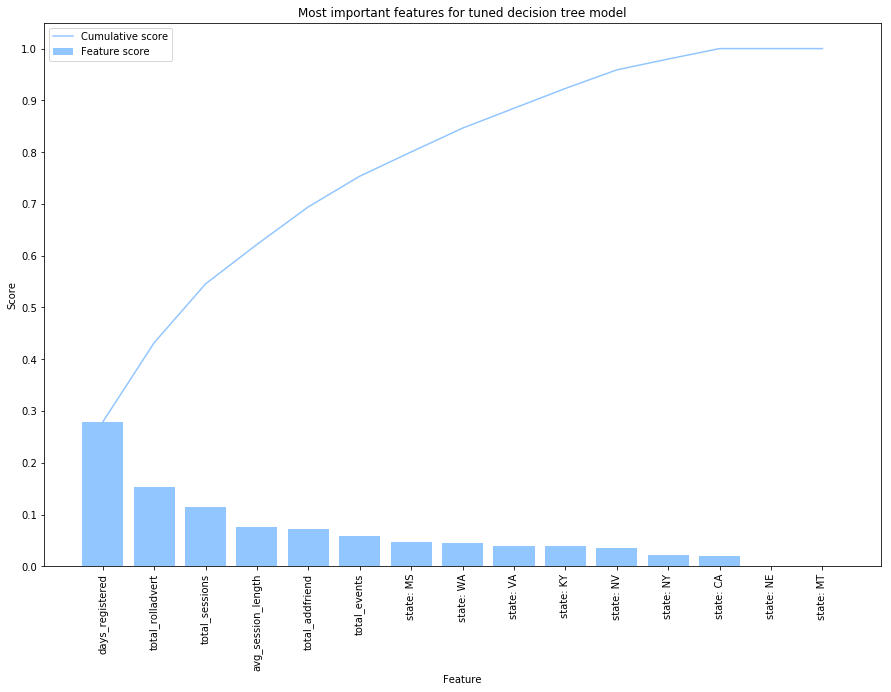

```python
# plot feature score and cumulative score for most important features for tuned decision tree model
# keep only top 15 most important features for plotting
df_feat_imp_dt_15 = df_feat_imp_dt.head(15)

ind = np.arange(len(df_feat_imp_dt_15['name']))

fig = plt.figure(figsize = (15,10))
plt.bar(ind, df_feat_imp_dt_15['score'], label='Feature score')
plt.plot(ind, df_feat_imp_dt_15['cumulative_score'], label='Cumulative score')
plt.title('Most important features for tuned decision tree model')
plt.legend(loc='upper left')
plt.ylabel('Score')
plt.yticks(np.arange(0, 1.1, step=0.1))
plt.xlabel('Feature')
plt.xticks(ind, df_feat_imp_dt_15['name'], rotation=90)
plt.show()
```

**Above we can see the top 15 most important features to the tuned decision tree model in predicting churn. The score is the weight of the feature, and the higher the weight the more important the feature is to the model. The weight of a feature indicates its predictive power. The cumulative score shows the total predictive power of a feature and its previous features.**

**The most important features to the model seem to be days_registered and total_rolladvert, which have a predictive power of 28% and 15% respectively. This means that looking at how long a user has been registered on the platform and the number of ads they have received are most important in predicting whether they will churn.**

**If we look at the 7 most important features, they have a combined predictive power of 80%, so we could narrow down our feature selection to these 7 and still have a model that has a predictive power of 80%. We could test the performance of that model and if it's good enough we would have a more simple and faster model that needs less data to predict on.**

**To continue our model evaluation we need to move to the bigger dataset to be able to train and test the models properly. We should also explore if we can reduce the number of inut features to see if we can make a more efficient model that still performs good enough. I will keep to the initial analysis I've conducted here and only look at basic plots and statistics of the columns I have already decided to include in the modeling for the bigger dataset. My main focus for the bigger dataset will be model optimization and selection.**